# codeBLIZ

Task1.4 - Climate and land-use scenarios

Afonso Barrocal

2024-05-28

# METHODS

This step is divided into three substeps: (1) downloading and processing the climate variables; (2) downloading and processing land use variables; and (3) combine climate scenarios and land use scenarios.

## 1 – CLIMATIC VARIABLES

Two climatic variables were used: Annual Mean Air Temperature (bio01) and the Annual Precipitation (bio12). The climatic variables are available in four 30-year intervals (1981-2010, 2011-2040, 2041-2070, and 2071-2100) at a resolution of 1km for three climate scenarios. In this work, the SSP126 and SSP585 scenarios are used. Climate variable layers are available in five global circulation models (GCM; GFDL-ESM4, IPSL-CM6A-LR, MPI-ESM1-2-HR, MRI-ESM2-0, and UKESM1-0-LL). In order to make climate data compatible with land use data, the layers used are the average of the available GCM layers. All climate layers are available in the [CHELSA Version 2.1](https://chelsa-climate.org/downloads/) database (Karger et al., 2017).

The climatic data was extracted and processed using the package `terra` (Hijmans, 2024) and the package `sf` (Pebesma, 2018) in the R software (R Core Team, 2022).

### 1.1 – Extracting the climatic data

First, we import the occurrence data of the target species collected in the previous step.

```r
# load package
library("data.table")

# import data
Amillefolium <- fread("occ/Achillea_millefolium_occurrences/0032263-231120084113126.csv",
                           stringsAsFactors=TRUE)
invisible(gc()) # to empty the memory
Evaginatum <- fread("occ/Eriophorum_vaginatum_occurrences/0203268-240321170329656.csv",
                       stringsAsFactors=TRUE)
invisible(gc()) # to empty the memory
Fsylvatica <- fread("occ/Fagus_sylvatica_occurrences/0203271-240321170329656.csv",
                       stringsAsFactors=TRUE)
invisible(gc()) # to empty the memory
Planceolata <- fread("occ/Plantago_lanceolata_occurrences/0038643-231120084113126.csv",
                          stringsAsFactors=TRUE)
invisible(gc()) # to empty the memory
Ppratensis <- fread("occ/Poa_pratensis_occurrences/0203436-240321170329656.csv",
                      stringsAsFactors=TRUE)
invisible(gc()) # to empty the memory
Ptrivialis <- fread("occ/Poa_trivialis_occurrences/0203438-240321170329656.csv",
                          stringsAsFactors=TRUE)
invisible(gc()) # to empty the memory
Racris <- fread("occ/Ranunculus_acris_occurrences/0203502-240321170329656.csv",
                           stringsAsFactors=TRUE)
invisible(gc()) # to empty the memory
Rbulbosus <- fread("occ/Ranunculus_bulbosus_occurrences/0203503-240321170329656.csv",
                       stringsAsFactors=TRUE)
invisible(gc()) # to empty the memory
Racetosa <- fread("occ/Rumex_acetosa_occurrences/0038676-231120084113126.csv",
                       stringsAsFactors=TRUE)
invisible(gc()) # to empty the memory
Vchamaedrys <- fread("occ/Veronica_chamaedrys_occurrences/0038695-231120084113126.csv",
                          stringsAsFactors=TRUE)
invisible(gc()) # to empty the memory
Varvensis <- fread("occ/Viola_arvensis_occurrences/0203505-240321170329656.csv",
                      stringsAsFactors=TRUE)
invisible(gc()) # to empty the memory

# creating list of species (los)
los <- list(Amillefolium,Evaginatum,Fsylvatica,Planceolata,Ppratensis,Ptrivialis,Racris,Rbulbosus,Racetosa,Vchamaedrys,Varvensis)

# removing heavy datasets
rm(Amillefolium,Evaginatum,Fsylvatica,Planceolata,Ppratensis,Ptrivialis,Racris,Rbulbosus,Racetosa,Vchamaedrys,Varvensis)
invisible(gc()) # to empty the memory
```

```
## [1] "COMPLETED IN..."
```

```
## Time difference of 3.114424 mins
```

Secondly, we use the package `terra` to import the desired climate layers (bio01 and bio12 from the 1981-2010 interval). After the occurrences and climate data have been imported, the extract function of the package `terra` is used to extract the values of the desired variables at the occurrence points. Thirdly, we calculate the mode, maximum and minimum of the desired climate variables, based on the values extracted from species occurrences, which serve as a proxy for the optimum, the upper limit and the lower limit, respectively, of precipitation and temperature for each species.

```r
# environmental variable values function
getEValues <- function(vector){

  # processing dataset
  points <- subset(vector, select = c("decimalLongitude","decimalLatitude"))
  colnames(points) <- c("x","y")

  # load required package
  require("terra", quietly = T)

  # import environmental variables raster (from the CHELSA database)
  pr <- rast("clim/1981_2010/bio12.tif") # annual precipitation
  invisible(gc()) # to empty the memory
  tc <- rast("clim/1981_2010/bio01.tif") # annual mean air temperature
  invisible(gc()) # to empty the memory

  # stacking raster
  EV <- c(tc,pr)
  invisible(gc()) # to empty the memory

  # extract values
  points <- as.data.frame(points)
  valuesatpoints <- extract(EV, points)
  invisible(gc()) # to empty the memory
  points <- cbind(points,valuesatpoints)
  colnames(points) <- c("lon","lat","ID","bio01","bio12")

  # mode function
  mode <- function(v) {
    uniqv <- unique(v)
    uniqv[which.max(tabulate(match(v, uniqv)))]
  }

  # creating dataframe
  climate <- data.frame(`species` = unique(vector$species),
                        `upper_limit_temperature` = max(points$bio01, na.rm = T),
                        `upper_limit_precipitation` = max(points$bio12, na.rm = T),
                        `lower_limit_temperature` = min(points$bio01, na.rm = T),
                        `lower_limit_precipitation` = min(points$bio12, na.rm = T),
                        `sd_temperature` = sd(points$bio01, na.rm = T),
                        `sd_precipitation` = sd(points$bio12, na.rm = T),
                        `optimum_temperature` = mode(points$bio01),
                        `optimum_precipitation` = mode(points$bio12),
                        `mean_temperature` = mean(points$bio01, na.rm = T),
                        `mean_precipitation` = mean(points$bio12, na.rm = T))
  invisible(gc())
  return(climate)
}

# run the list of species through the function and combine the result into a single dataframe
dataset_climate <- as.data.frame(do.call(rbind, lapply(los,getEValues)))
invisible(gc()) # to empty the memory

# see resulting dataframe
rmarkdown::paged_table(dataset_climate)
```

| species | upper_limit_temperature | upper_limit_precipitation | lower_limit_temperature | lower_limit_precipitation | sd_temperature | sd_precipitation | optimum_temperature | optimum_precipitation | mean_temperature | mean_precipitation |
| --- | --- | --- | --- | --- | --- | --- | --- | --- | --- | --- |
| Achillea millefolium | 27.25 | 6553.5 | -16.15 | 107.5 | 2.874581 | 345.8324 | 10.35 | 874.0 | 8.783038 | 945.0521 |
| Eriophorum vaginatum | 17.55 | 5965.4 | -17.15 | 129.0 | 3.170482 | 542.6656 | 8.55 | 1944.3 | 5.846151 | 1127.3552 |
| Fagus sylvatica | 19.65 | 4923.0 | -5.35 | 328.9 | 1.844686 | 350.2315 | 11.55 | 919.2 | 9.096382 | 1040.6491 |
| Plantago lanceolata | 27.75 | 6553.5 | -9.85 | 19.5 | 2.342155 | 358.9838 | 10.35 | 857.9 | 9.983846 | 979.7682 |
| Poa pratensis | 24.35 | 6553.5 | -18.15 | 67.9 | 2.471540 | 274.0764 | 10.35 | 510.2 | 9.072277 | 894.9493 |
| Poa trivialis | 25.95 | 6553.5 | -9.65 | 175.2 | 1.851628 | 284.0704 | 10.25 | 907.2 | 9.671238 | 928.0418 |
| Ranunculus acris | 26.95 | 6553.5 | -9.05 | 225.3 | 2.624866 | 379.3308 | 10.55 | 857.9 | 8.856812 | 1003.2927 |
| Ranunculus bulbosus | 22.65 | 5754.4 | -6.95 | 321.9 | 2.132119 | 295.7017 | 10.35 | 835.9 | 9.961388 | 954.3421 |
| Rumex acetosa | 26.35 | 6553.5 | -27.95 | 106.5 | 2.384649 | 371.7823 | 10.15 | 907.2 | 8.893068 | 998.2416 |
| Veronica chamaedrys | 24.35 | 4946.8 | -9.25 | 196.1 | 2.393493 | 386.8253 | 10.15 | 880.7 | 8.664146 | 1008.5845 |

[output cut: 1 more lines]

```r
# export climatic information
write.csv(dataset_climate, "climate.csv",
          row.names = FALSE)

# remove unnecessary objects
rm(dataset_climate,getEValues)
invisible(gc())
```

```
## [1] "COMPLETED IN..."
```

```
## Time difference of 6.239607 mins
```

### 1.2 – Adding the temperature and precipitation values to the species profile

With the upper limit, lower limit and optimum temperature and precipitation values calculated for each species and with the trait values calculated in the previous step, we create the species file for each species so that it can be used as input for the MetaRange model.

```r
# load package
library("data.table")

# import trait data
trait_data <- fread("trait_data.csv")
invisible(gc())

# remove rownames
trait_data <- trait_data[,-c(1,3,4,11,12,16,17)]
invisible(gc())

# creating vector with correct argument names
names <- c("species_name","carry","mass","bevmort",
           "mean_dispersal_dist","max_dispersal_dist",
           "growrate","sd_carry","sd_mass","sd_bevmort",
           "sd_growrate")

# processing trait data (changing names)
colnames(trait_data) <- names

# remove unnecessary objects
rm(names)
invisible(gc())

# import climatic data
climate <- read.csv("climate.csv", stringsAsFactors=TRUE)
invisible(gc())

# processing climate data
climate <- climate[,-c(6,7,10,11)]

# processing climate data (change first collumn name)
colnames(climate) <- c("species_name",colnames(climate)[-1])

# merge trait and climatic data
data <- merge(trait_data,climate)
invisible(gc())

# remove unnecessary objects
rm(trait_data)
invisible(gc())

# change format to data frame
data <- as.data.frame(data)

# process merged data to the desirable format
data$species_name <- sub(" ", "_", data$species_name)

data$species_name <- tolower(as.character(data$species_name))

data$species_name <- as.factor(data$species_name)

# create new collumn (cut-off value)
data$habitat_cutoff_suitability <- rep(0.01,11)

# create new collumn (allee effect)
data$allee <- rep(0,11)
data$sd_allee <- rep(0,11)

# (re-)order data table
data <- data[,c(1,3,9,7,11,6,5,19,20,4,10,2,8,12,14,13,15,18,16,17)]

# create vector with collumn names
a <- colnames(data)

# load package
library("data.table")

# change format to data table
data <- data.table(data)

# transpose data table
dataT <- transpose(data)

# remove unnecessary objects
rm(data)
invisible(gc())

# create "Argument" collumn
dataT$Argument <- a

# (re-)order data table
dataT <- dataT[,c(12,1,2,3,4,5,6,7,8,9,10,11)]

# export a csv file with all the species
write.csv(dataT,"species_files.csv",row.names = F)

# import data for all the species
dataT <- read.csv("species_files.csv", stringsAsFactors=TRUE)

# create a loop to export input file for each species
for(i in seq_along(climate$species_name)){

  df <- dataT[,c(1,i+1)]

  colnames(df) <- c("Argument","Value")

  library("stringr")

  b <- sub(" ", "", str_to_title(as.character(climate$species[i])))

  write.table(df,paste0("outputs/",b,"/SSP1 - climate + land use/species/",b,".csv"),
              col.names = T, row.names = F, sep = " ",
              quote = FALSE)

  write.table(df,paste0("outputs/",b,"/SSP5 - climate + land use/species/",b,".csv"),
              col.names = T, row.names = F, sep = " ",
              quote = FALSE)

  write.table(df,paste0("outputs/",b,"/SSP1 - climate/species/",b,".csv"),
              col.names = T, row.names = F, sep = " ",
              quote = FALSE)

  write.table(df,paste0("outputs/",b,"/SSP5 - climate/species/",b,".csv"),
              col.names = T, row.names = F, sep = " ",
              quote = FALSE)

  write.table(df,paste0("outputs/",b,"/SSP1 - land use/species/",b,".csv"),
              col.names = T, row.names = F, sep = " ",
              quote = FALSE)

  write.table(df,paste0("outputs/",b,"/SSP5 - land use/species/",b,".csv"),
              col.names = T, row.names = F, sep = " ",
              quote = FALSE)

  invisible(gc())

}

# remove unnecessary objects
rm(climate,a,i,b,df,dataT)
invisible(gc())
```

```
## [1] "COMPLETED IN..."
```

```
## Time difference of 1.124695 mins
```

### 1.3 – Clipping and Exporting the Climate Data

In addition to the species files (input ecophysiological data of the target species), for the model to run, it is also necessary to export the layers of climate variables for the desired intervals and climate scenarios (2011-2040, 2041-2070, 2071-2100; SSP126 and SSP585; respectively) clipped so that only the Bavaria and Baden-Württemberg area are included. For this purpose, the package `terra` (Hijmans, 2024) and the package `sf` (Pebesma, 2018) were used. Before being exported, the climate rasters were aggregated by a factor 6 and then resampled to match the resolution of the land-use files, this is done using the package `terra` (Hijmans, 2024).

```r
# load package
library("terra")

# creating necessary function
state <- function(x) {
  print(substitute(x))
}

# creating lists for precipitation raster (2011-2040 SSP126)
l1 <- list("https://os.zhdk.cloud.switch.ch/envicloud/chelsa/chelsa_V2/GLOBAL/climatologies/2011-2040/GFDL-ESM4/ssp126/bio/CHELSA_bio12_2011-2040_gfdl-esm4_ssp126_V.2.1.tif",
           "https://os.zhdk.cloud.switch.ch/envicloud/chelsa/chelsa_V2/GLOBAL/climatologies/2011-2040/IPSL-CM6A-LR/ssp126/bio/CHELSA_bio12_2011-2040_ipsl-cm6a-lr_ssp126_V.2.1.tif",
           "https://os.zhdk.cloud.switch.ch/envicloud/chelsa/chelsa_V2/GLOBAL/climatologies/2011-2040/MPI-ESM1-2-HR/ssp126/bio/CHELSA_bio12_2011-2040_mpi-esm1-2-hr_ssp126_V.2.1.tif",
           "https://os.zhdk.cloud.switch.ch/envicloud/chelsa/chelsa_V2/GLOBAL/climatologies/2011-2040/MRI-ESM2-0/ssp126/bio/CHELSA_bio12_2011-2040_mri-esm2-0_ssp126_V.2.1.tif",
           "https://os.zhdk.cloud.switch.ch/envicloud/chelsa/chelsa_V2/GLOBAL/climatologies/2011-2040/UKESM1-0-LL/ssp126/bio/CHELSA_bio12_2011-2040_ukesm1-0-ll_ssp126_V.2.1.tif")

# calculating the mean of all the GCMs
start <- Sys.time()
bio12_126_2011_2040 <- mean(do.call(c,lapply(l1,rast)))
names(bio12_126_2011_2040) <- "bio12"
varnames(bio12_126_2011_2040) <- "bio12_126_2011_2040"
longnames(bio12_126_2011_2040) <- "bio12_126_2011_2040"
writeRaster(bio12_126_2011_2040,
            filename = paste0("clim/Future/",state(bio12_126_2011_2040),".tif"), overwrite=TRUE)
rm(bio12_126_2011_2040)
end <- Sys.time()
end-start

# creating lists for temperature raster (2011-2040 SSP126)
l2 <- list("https://os.zhdk.cloud.switch.ch/envicloud/chelsa/chelsa_V2/GLOBAL/climatologies/2011-2040/GFDL-ESM4/ssp126/bio/CHELSA_bio1_2011-2040_gfdl-esm4_ssp126_V.2.1.tif",
           "https://os.zhdk.cloud.switch.ch/envicloud/chelsa/chelsa_V2/GLOBAL/climatologies/2011-2040/IPSL-CM6A-LR/ssp126/bio/CHELSA_bio1_2011-2040_ipsl-cm6a-lr_ssp126_V.2.1.tif",
           "https://os.zhdk.cloud.switch.ch/envicloud/chelsa/chelsa_V2/GLOBAL/climatologies/2011-2040/MPI-ESM1-2-HR/ssp126/bio/CHELSA_bio1_2011-2040_mpi-esm1-2-hr_ssp126_V.2.1.tif",
           "https://os.zhdk.cloud.switch.ch/envicloud/chelsa/chelsa_V2/GLOBAL/climatologies/2011-2040/MRI-ESM2-0/ssp126/bio/CHELSA_bio1_2011-2040_mri-esm2-0_ssp126_V.2.1.tif",
           "https://os.zhdk.cloud.switch.ch/envicloud/chelsa/chelsa_V2/GLOBAL/climatologies/2011-2040/UKESM1-0-LL/ssp126/bio/CHELSA_bio1_2011-2040_ukesm1-0-ll_ssp126_V.2.1.tif")

# calculating the mean of all the GCMs
start <- Sys.time()
bio01_126_2011_2040 <- mean(do.call(c,lapply(l2,rast)))
names(bio01_126_2011_2040) <- "bio1"
varnames(bio01_126_2011_2040) <- "bio01_126_2011_2040"
longnames(bio01_126_2011_2040) <- "bio01_126_2011_2040"
writeRaster(bio01_126_2011_2040,
            filename = paste0("clim/Future/",state(bio01_126_2011_2040),".tif"), overwrite=TRUE)
rm(bio01_126_2011_2040)
end <- Sys.time()
end-start

# creating lists for precipitation raster (2011-2040 SSP585)
l3 <- list("https://os.zhdk.cloud.switch.ch/envicloud/chelsa/chelsa_V2/GLOBAL/climatologies/2011-2040/GFDL-ESM4/ssp585/bio/CHELSA_bio12_2011-2040_gfdl-esm4_ssp585_V.2.1.tif",
           "https://os.zhdk.cloud.switch.ch/envicloud/chelsa/chelsa_V2/GLOBAL/climatologies/2011-2040/IPSL-CM6A-LR/ssp585/bio/CHELSA_bio12_2011-2040_ipsl-cm6a-lr_ssp585_V.2.1.tif",
           "https://os.zhdk.cloud.switch.ch/envicloud/chelsa/chelsa_V2/GLOBAL/climatologies/2011-2040/MPI-ESM1-2-HR/ssp585/bio/CHELSA_bio12_2011-2040_mpi-esm1-2-hr_ssp585_V.2.1.tif",
           "https://os.zhdk.cloud.switch.ch/envicloud/chelsa/chelsa_V2/GLOBAL/climatologies/2011-2040/MRI-ESM2-0/ssp585/bio/CHELSA_bio12_2011-2040_mri-esm2-0_ssp585_V.2.1.tif",
           "https://os.zhdk.cloud.switch.ch/envicloud/chelsa/chelsa_V2/GLOBAL/climatologies/2011-2040/UKESM1-0-LL/ssp585/bio/CHELSA_bio12_2011-2040_ukesm1-0-ll_ssp585_V.2.1.tif")

# calculating the mean of all the GCMs
start <- Sys.time()
bio12_585_2011_2040 <- mean(do.call(c,lapply(l3,rast)))
names(bio12_585_2011_2040) <- "bio12"
varnames(bio12_585_2011_2040) <- "bio12_585_2011_2040"
longnames(bio12_585_2011_2040) <- "bio12_585_2011_2040"
writeRaster(bio12_585_2011_2040,
            filename = paste0("clim/Future/",state(bio12_585_2011_2040),".tif"), overwrite=TRUE)
rm(bio12_585_2011_2040)
end <- Sys.time()
end-start

# creating lists for temperature raster (2011-2040 SSP585)
l4 <- list("https://os.zhdk.cloud.switch.ch/envicloud/chelsa/chelsa_V2/GLOBAL/climatologies/2011-2040/GFDL-ESM4/ssp585/bio/CHELSA_bio1_2011-2040_gfdl-esm4_ssp585_V.2.1.tif",
           "https://os.zhdk.cloud.switch.ch/envicloud/chelsa/chelsa_V2/GLOBAL/climatologies/2011-2040/IPSL-CM6A-LR/ssp585/bio/CHELSA_bio1_2011-2040_ipsl-cm6a-lr_ssp585_V.2.1.tif",
           "https://os.zhdk.cloud.switch.ch/envicloud/chelsa/chelsa_V2/GLOBAL/climatologies/2011-2040/MPI-ESM1-2-HR/ssp585/bio/CHELSA_bio1_2011-2040_mpi-esm1-2-hr_ssp585_V.2.1.tif",
           "https://os.zhdk.cloud.switch.ch/envicloud/chelsa/chelsa_V2/GLOBAL/climatologies/2011-2040/MRI-ESM2-0/ssp585/bio/CHELSA_bio1_2011-2040_mri-esm2-0_ssp585_V.2.1.tif",
           "https://os.zhdk.cloud.switch.ch/envicloud/chelsa/chelsa_V2/GLOBAL/climatologies/2011-2040/UKESM1-0-LL/ssp585/bio/CHELSA_bio1_2011-2040_ukesm1-0-ll_ssp585_V.2.1.tif")

# calculating the mean of all the GCMs
start <- Sys.time()
bio01_585_2011_2040 <- mean(do.call(c,lapply(l4,rast)))
names(bio01_585_2011_2040) <- "bio1"
varnames(bio01_585_2011_2040) <- "bio01_585_2011_2040"
longnames(bio01_585_2011_2040) <- "bio01_585_2011_2040"
writeRaster(bio01_585_2011_2040,
            filename = paste0("clim/Future/",state(bio01_585_2011_2040),".tif"), overwrite=TRUE)
rm(bio01_585_2011_2040)
end <- Sys.time()
end-start

# creating lists for precipitation raster (2041-2070 SSP126)
l5 <- list("https://os.zhdk.cloud.switch.ch/envicloud/chelsa/chelsa_V2/GLOBAL/climatologies/2041-2070/GFDL-ESM4/ssp126/bio/CHELSA_bio12_2041-2070_gfdl-esm4_ssp126_V.2.1.tif",
           "https://os.zhdk.cloud.switch.ch/envicloud/chelsa/chelsa_V2/GLOBAL/climatologies/2041-2070/IPSL-CM6A-LR/ssp126/bio/CHELSA_bio12_2041-2070_ipsl-cm6a-lr_ssp126_V.2.1.tif",
           "https://os.zhdk.cloud.switch.ch/envicloud/chelsa/chelsa_V2/GLOBAL/climatologies/2041-2070/MPI-ESM1-2-HR/ssp126/bio/CHELSA_bio12_2041-2070_mpi-esm1-2-hr_ssp126_V.2.1.tif",
           "https://os.zhdk.cloud.switch.ch/envicloud/chelsa/chelsa_V2/GLOBAL/climatologies/2041-2070/MRI-ESM2-0/ssp126/bio/CHELSA_bio12_2041-2070_mri-esm2-0_ssp126_V.2.1.tif",
           "https://os.zhdk.cloud.switch.ch/envicloud/chelsa/chelsa_V2/GLOBAL/climatologies/2041-2070/UKESM1-0-LL/ssp126/bio/CHELSA_bio12_2041-2070_ukesm1-0-ll_ssp126_V.2.1.tif")
```

```r
# calculating the mean of all the GCMs
start <- Sys.time()
bio12_126_2041_2070 <- mean(do.call(c,lapply(l5,rast)))
names(bio12_126_2041_2070) <- "bio12"
varnames(bio12_126_2041_2070) <- "bio12_126_2041_2070"
longnames(bio12_126_2041_2070) <- "bio12_126_2041_2070"
writeRaster(bio12_126_2041_2070,
            filename = paste0("clim/Future/",state(bio12_126_2041_2070),".tif"), overwrite=TRUE)
rm(bio12_126_2041_2070)
end <- Sys.time()
end-start

# creating lists for temperature raster (2041-2070 SSP126)
l6 <- list("https://os.zhdk.cloud.switch.ch/envicloud/chelsa/chelsa_V2/GLOBAL/climatologies/2041-2070/GFDL-ESM4/ssp126/bio/CHELSA_bio1_2041-2070_gfdl-esm4_ssp126_V.2.1.tif",
           "https://os.zhdk.cloud.switch.ch/envicloud/chelsa/chelsa_V2/GLOBAL/climatologies/2041-2070/IPSL-CM6A-LR/ssp126/bio/CHELSA_bio1_2041-2070_ipsl-cm6a-lr_ssp126_V.2.1.tif",
           "https://os.zhdk.cloud.switch.ch/envicloud/chelsa/chelsa_V2/GLOBAL/climatologies/2041-2070/MPI-ESM1-2-HR/ssp126/bio/CHELSA_bio1_2041-2070_mpi-esm1-2-hr_ssp126_V.2.1.tif",
           "https://os.zhdk.cloud.switch.ch/envicloud/chelsa/chelsa_V2/GLOBAL/climatologies/2041-2070/MRI-ESM2-0/ssp126/bio/CHELSA_bio1_2041-2070_mri-esm2-0_ssp126_V.2.1.tif",
           "https://os.zhdk.cloud.switch.ch/envicloud/chelsa/chelsa_V2/GLOBAL/climatologies/2041-2070/UKESM1-0-LL/ssp126/bio/CHELSA_bio1_2041-2070_ukesm1-0-ll_ssp126_V.2.1.tif")

# calculating the mean of all the GCMs
start <- Sys.time()
bio01_126_2041_2070 <- mean(do.call(c,lapply(l6,rast)))
names(bio01_126_2041_2070) <- "bio1"
varnames(bio01_126_2041_2070) <- "bio1"
longnames(bio01_126_2041_2070) <- "bio1"
writeRaster(bio01_126_2041_2070,
            filename = paste0("clim/Future/",state(bio01_126_2041_2070),".tif"), overwrite=TRUE)
rm(bio01_126_2041_2070)
end <- Sys.time()
end-start

# creating lists for precipitation raster (2041-2070 SSP585)
l7 <- list("https://os.zhdk.cloud.switch.ch/envicloud/chelsa/chelsa_V2/GLOBAL/climatologies/2041-2070/GFDL-ESM4/ssp585/bio/CHELSA_bio12_2041-2070_gfdl-esm4_ssp585_V.2.1.tif",
           "https://os.zhdk.cloud.switch.ch/envicloud/chelsa/chelsa_V2/GLOBAL/climatologies/2041-2070/IPSL-CM6A-LR/ssp585/bio/CHELSA_bio12_2041-2070_ipsl-cm6a-lr_ssp585_V.2.1.tif",
           "https://os.zhdk.cloud.switch.ch/envicloud/chelsa/chelsa_V2/GLOBAL/climatologies/2041-2070/MPI-ESM1-2-HR/ssp585/bio/CHELSA_bio12_2041-2070_mpi-esm1-2-hr_ssp585_V.2.1.tif",
           "https://os.zhdk.cloud.switch.ch/envicloud/chelsa/chelsa_V2/GLOBAL/climatologies/2041-2070/MRI-ESM2-0/ssp585/bio/CHELSA_bio12_2041-2070_mri-esm2-0_ssp585_V.2.1.tif",
           "https://os.zhdk.cloud.switch.ch/envicloud/chelsa/chelsa_V2/GLOBAL/climatologies/2041-2070/UKESM1-0-LL/ssp585/bio/CHELSA_bio12_2041-2070_ukesm1-0-ll_ssp585_V.2.1.tif")

# calculating the mean of all the GCMs
start <- Sys.time()
bio12_585_2041_2070 <- mean(do.call(c,lapply(l7,rast)))
names(bio12_585_2041_2070) <- "bio12"
writeRaster(bio12_585_2041_2070,
            filename = paste0("clim/Future/",state(bio12_585_2041_2070),".tif"), overwrite=TRUE)
rm(bio12_585_2041_2070)
end <- Sys.time()
end-start

# creating lists for temperature raster (2041-2070 SSP585)
l8 <- list("https://os.zhdk.cloud.switch.ch/envicloud/chelsa/chelsa_V2/GLOBAL/climatologies/2041-2070/GFDL-ESM4/ssp585/bio/CHELSA_bio1_2041-2070_gfdl-esm4_ssp585_V.2.1.tif",
           "https://os.zhdk.cloud.switch.ch/envicloud/chelsa/chelsa_V2/GLOBAL/climatologies/2041-2070/IPSL-CM6A-LR/ssp585/bio/CHELSA_bio1_2041-2070_ipsl-cm6a-lr_ssp585_V.2.1.tif",
           "https://os.zhdk.cloud.switch.ch/envicloud/chelsa/chelsa_V2/GLOBAL/climatologies/2041-2070/MPI-ESM1-2-HR/ssp585/bio/CHELSA_bio1_2041-2070_mpi-esm1-2-hr_ssp585_V.2.1.tif",
           "https://os.zhdk.cloud.switch.ch/envicloud/chelsa/chelsa_V2/GLOBAL/climatologies/2041-2070/MRI-ESM2-0/ssp585/bio/CHELSA_bio1_2041-2070_mri-esm2-0_ssp585_V.2.1.tif",
           "https://os.zhdk.cloud.switch.ch/envicloud/chelsa/chelsa_V2/GLOBAL/climatologies/2041-2070/UKESM1-0-LL/ssp585/bio/CHELSA_bio1_2041-2070_ukesm1-0-ll_ssp585_V.2.1.tif")

# calculating the mean of all the GCMs
start <- Sys.time()
bio01_585_2041_2070 <- mean(do.call(c,lapply(l8,rast)))
names(bio01_585_2041_2070) <- "bio1"
writeRaster(bio01_585_2041_2070,
            filename = paste0("clim/Future/",state(bio01_585_2041_2070),".tif"), overwrite=TRUE)
rm(bio01_585_2041_2070)
end <- Sys.time()
end-start

# creating lists for precipitation raster (2071-2100 SSP126)
l9 <- list("https://os.zhdk.cloud.switch.ch/envicloud/chelsa/chelsa_V2/GLOBAL/climatologies/2071-2100/GFDL-ESM4/ssp126/bio/CHELSA_bio12_2071-2100_gfdl-esm4_ssp126_V.2.1.tif",
           "https://os.zhdk.cloud.switch.ch/envicloud/chelsa/chelsa_V2/GLOBAL/climatologies/2071-2100/IPSL-CM6A-LR/ssp126/bio/CHELSA_bio12_2071-2100_ipsl-cm6a-lr_ssp126_V.2.1.tif",
           "https://os.zhdk.cloud.switch.ch/envicloud/chelsa/chelsa_V2/GLOBAL/climatologies/2071-2100/MPI-ESM1-2-HR/ssp126/bio/CHELSA_bio12_2071-2100_mpi-esm1-2-hr_ssp126_V.2.1.tif",
           "https://os.zhdk.cloud.switch.ch/envicloud/chelsa/chelsa_V2/GLOBAL/climatologies/2071-2100/MRI-ESM2-0/ssp126/bio/CHELSA_bio12_2071-2100_mri-esm2-0_ssp126_V.2.1.tif",
           "https://os.zhdk.cloud.switch.ch/envicloud/chelsa/chelsa_V2/GLOBAL/climatologies/2071-2100/UKESM1-0-LL/ssp126/bio/CHELSA_bio12_2071-2100_ukesm1-0-ll_ssp126_V.2.1.tif")

# calculating the mean of all the GCMs
start <- Sys.time()
bio12_126_2071_2100 <- mean(do.call(c,lapply(l9,rast)))
names(bio12_126_2071_2100) <- "bio12"
writeRaster(bio12_126_2071_2100,
            filename = paste0("clim/Future/",state(bio12_126_2071_2100),".tif"), overwrite=TRUE)
rm(bio12_126_2071_2100)
end <- Sys.time()
end-start

# creating lists for temperature raster (2071-2100 SSP126)
l10 <- list("https://os.zhdk.cloud.switch.ch/envicloud/chelsa/chelsa_V2/GLOBAL/climatologies/2071-2100/GFDL-ESM4/ssp126/bio/CHELSA_bio1_2071-2100_gfdl-esm4_ssp126_V.2.1.tif",
           "https://os.zhdk.cloud.switch.ch/envicloud/chelsa/chelsa_V2/GLOBAL/climatologies/2071-2100/IPSL-CM6A-LR/ssp126/bio/CHELSA_bio1_2071-2100_ipsl-cm6a-lr_ssp126_V.2.1.tif",
           "https://os.zhdk.cloud.switch.ch/envicloud/chelsa/chelsa_V2/GLOBAL/climatologies/2071-2100/MPI-ESM1-2-HR/ssp126/bio/CHELSA_bio1_2071-2100_mpi-esm1-2-hr_ssp126_V.2.1.tif",
           "https://os.zhdk.cloud.switch.ch/envicloud/chelsa/chelsa_V2/GLOBAL/climatologies/2071-2100/MRI-ESM2-0/ssp126/bio/CHELSA_bio1_2071-2100_mri-esm2-0_ssp126_V.2.1.tif",
           "https://os.zhdk.cloud.switch.ch/envicloud/chelsa/chelsa_V2/GLOBAL/climatologies/2071-2100/UKESM1-0-LL/ssp126/bio/CHELSA_bio1_2071-2100_ukesm1-0-ll_ssp126_V.2.1.tif")
```

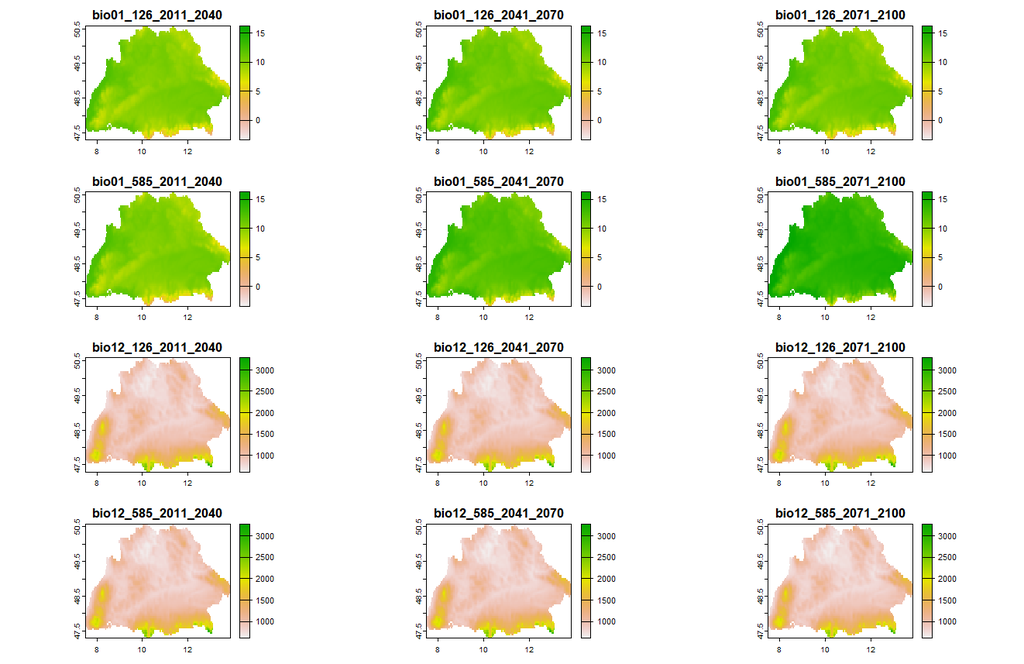

```r
# calculating the mean of all the GCMs
start <- Sys.time()
bio01_126_2071_2100 <- mean(do.call(c,lapply(l10,rast)))
names(bio01_126_2071_2100) <- "bio1"
writeRaster(bio01_126_2071_2100,
            filename = paste0("clim/Future/",state(bio01_126_2071_2100),".tif"), overwrite=TRUE)
rm(bio01_126_2071_2100)
end <- Sys.time()
end-start

# creating lists for precipitation raster (2071-2100 SSP585)
l11 <- list("https://os.zhdk.cloud.switch.ch/envicloud/chelsa/chelsa_V2/GLOBAL/climatologies/2071-2100/GFDL-ESM4/ssp585/bio/CHELSA_bio12_2071-2100_gfdl-esm4_ssp585_V.2.1.tif",
           "https://os.zhdk.cloud.switch.ch/envicloud/chelsa/chelsa_V2/GLOBAL/climatologies/2071-2100/IPSL-CM6A-LR/ssp585/bio/CHELSA_bio12_2071-2100_ipsl-cm6a-lr_ssp585_V.2.1.tif",
           "https://os.zhdk.cloud.switch.ch/envicloud/chelsa/chelsa_V2/GLOBAL/climatologies/2071-2100/MPI-ESM1-2-HR/ssp585/bio/CHELSA_bio12_2071-2100_mpi-esm1-2-hr_ssp585_V.2.1.tif",
           "https://os.zhdk.cloud.switch.ch/envicloud/chelsa/chelsa_V2/GLOBAL/climatologies/2071-2100/MRI-ESM2-0/ssp585/bio/CHELSA_bio12_2071-2100_mri-esm2-0_ssp585_V.2.1.tif",
           "https://os.zhdk.cloud.switch.ch/envicloud/chelsa/chelsa_V2/GLOBAL/climatologies/2071-2100/UKESM1-0-LL/ssp585/bio/CHELSA_bio12_2071-2100_ukesm1-0-ll_ssp585_V.2.1.tif")

# calculating the mean of all the GCMs
start <- Sys.time()
bio12_585_2071_2100 <- mean(do.call(c,lapply(l11,rast)))
names(bio12_585_2071_2100) <- "bio12"
writeRaster(bio12_585_2071_2100,
            filename = paste0("clim/Future/",state(bio12_585_2071_2100),".tif"), overwrite=TRUE)
rm(bio12_585_2071_2100)
end <- Sys.time()
end-start

# creating lists for temperature raster (2071-2100 SSP585)
l12 <- list("https://os.zhdk.cloud.switch.ch/envicloud/chelsa/chelsa_V2/GLOBAL/climatologies/2071-2100/GFDL-ESM4/ssp585/bio/CHELSA_bio1_2071-2100_gfdl-esm4_ssp585_V.2.1.tif",
           "https://os.zhdk.cloud.switch.ch/envicloud/chelsa/chelsa_V2/GLOBAL/climatologies/2071-2100/IPSL-CM6A-LR/ssp585/bio/CHELSA_bio1_2071-2100_ipsl-cm6a-lr_ssp585_V.2.1.tif",
           "https://os.zhdk.cloud.switch.ch/envicloud/chelsa/chelsa_V2/GLOBAL/climatologies/2071-2100/MPI-ESM1-2-HR/ssp585/bio/CHELSA_bio1_2071-2100_mpi-esm1-2-hr_ssp585_V.2.1.tif",
           "https://os.zhdk.cloud.switch.ch/envicloud/chelsa/chelsa_V2/GLOBAL/climatologies/2071-2100/MRI-ESM2-0/ssp585/bio/CHELSA_bio1_2071-2100_mri-esm2-0_ssp585_V.2.1.tif",
           "https://os.zhdk.cloud.switch.ch/envicloud/chelsa/chelsa_V2/GLOBAL/climatologies/2071-2100/UKESM1-0-LL/ssp585/bio/CHELSA_bio1_2071-2100_ukesm1-0-ll_ssp585_V.2.1.tif")

# calculating the mean of all the GCMs
start <- Sys.time()
bio01_585_2071_2100 <- mean(do.call(c,lapply(l12,rast)))
names(bio01_585_2071_2100) <- "bio1"
writeRaster(bio01_585_2071_2100,
            filename = paste0("clim/Future/",state(bio01_585_2071_2100),".tif"), overwrite=TRUE)
rm(bio01_585_2071_2100)
end <- Sys.time()
end-start

# removing unnecessary objects
rm(l1,l2,l3,l4,l5,l6,l7,l8,l9,l10,l11,l12)

# importing present values (precipitation; 1981-2010)
bio12_1981_2010 <- rast("clim/1981_2010/bio12.tif")
names(bio12_1981_2010) <- "bio12"
varnames(bio12_1981_2010) <- "bio12_1981_2010"
longnames(bio12_1981_2010) <- "bio12_1981_2010"

# importing present values (temperature; 1981-2010)
bio01_1981_2010 <- rast("clim/1981_2010/bio01.tif")
names(bio01_1981_2010) <- "bio1"
varnames(bio01_1981_2010) <- "bio01_1981_2010"
longnames(bio01_1981_2010) <- "bio01_1981_2010"

###### croping and exporting ####

# load package
library("terra")

# import rasters
EVs <- rast(list.files("clim/Future/",
                       pattern = "tif", full.names=T))

# remove unnecessary objects
rm(bio01_1981_2010,bio12_1981_2010)

# load package
library("sf")

# import shapefile
shape <- read_sf("shapefiles/Bav_BW.shp")

# turn shapefile into SpatVector object
tShape <- vect(shape);rm(shape)

# crs
crs(EVs) <- crs(tShape)

# extent
BavBW <- crop(EVs, ext(tShape))

# masking time
# BavBW <- mask(EVs,tShape)
BavBW <- mask(BavBW,tShape)
a <- varnames(EVs)
names(BavBW) <- a

# aggregate data
xBavBW <- aggregate(BavBW, fact = 6, fun = "mean", na.rm = T)

# create dummy raster
s <- rast(nrow = 66,
          ncol = 127,
          xmin = 7.49895858764648,
          xmax = 13.8480768585205,
          ymin = 47.286860309177,
          ymax = 50.5859435865614)
crs(s)<- "epsg:4326"

# resampling to match the
nBavBW <- resample(xBavBW, s, method = "bilinear")

# remove unnecessary objects
rm(xBavBW,s)
invisible(gc())

# structuring
par(mfrow = c(4,3))

# plotting the clipped rasters
for(i in seq_along(names(BavBW))){
  if(i < 7){
    plot(nBavBW[[i]],
         range = c(-3.41,16.27),
         main = names(BavBW[[i]]))
  } else {
    plot(nBavBW[[i]],
         range = c(606.64,3283.36),
         main = names(BavBW[[i]]))
  }
}
```

*Figure 1* - Clipped Temperature (`bio01`) and Precipitation (`bio12`) over the study area, the Bavaria and Baden-Württemberg area, in Germany.

```r
# remove unnecessary objects
rm(i,EVs,tShape)
invisible(gc())

# cropping rasters
for(i in seq_along(names(nBavBW))){

  # now save as CSV in MetaRange format
  metarange <- round(as.array(nBavBW[[i]]))
  metarange[which(is.na(metarange))] <- "NaN"
  invisible(gc()) # garbage collection

  # Julia needs to have grid cells without values filled with "NaN"
  write.table(metarange,
              paste0("clim/Future/Cropped/",names(nBavBW)[i],".csv"),
              col.names = F, row.names = F)

  invisible(gc()) # garbage collection

  rm(metarange)

}

# removing unnecessary objects
rm(i,a,BavBW,nBavBW,state,end,start)
invisible(gc())
```

## 2 – LAND USE

The land use data is available in 5-year timesteps from 2015 to 2100 with a resolution of approximately 5km for fifteen climate scenarios and the same five GCMs available for climate data. In this work, the SSP 1 – RCP 2.6 and SSP 5 – RCP 8.5 scenarios and the average of the GCMs are used. All the land use layers are available in Chen et al. (2020). The land use data were used to calculate the habitat suitability of each species, according to the following scheme (Figure 2; see section 2.3). The land use data was extracted and processed using the package `terra` (Hijmans, 2024), the package `sf` (Pebesma, 2018), the package `ncdf4` (Pierce, 2023), the package `raster` (Hijmans, 2023), and the package `rgdal` (Bivand et al., 2023) in the R software (R Core Team, 2022).

### 2.1 – Selection of the Year for Extracting Land use Data

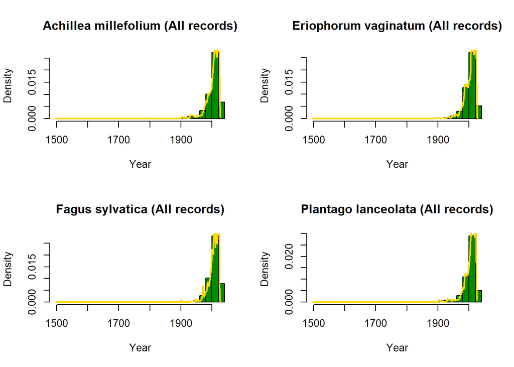

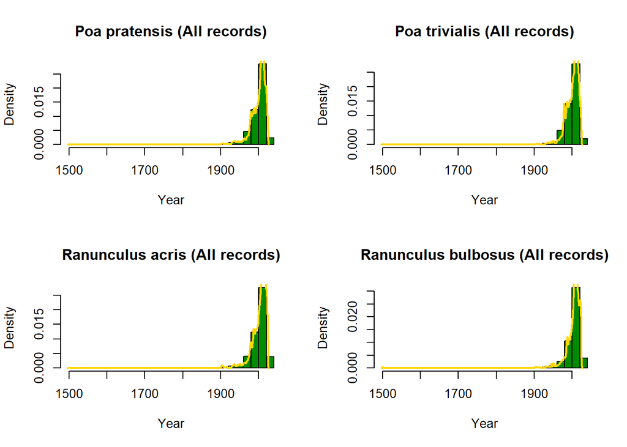

```r
# creating plotting function (from the oldest record to the present)
plantHist <- function(x){

  hist(x$year, probability = T,
       main = paste(unique(x$species), "(All records)"),
       xlab = "Year", col = "green4")
  lines(density(x$year, na.rm = T),
        col = "gold", lwd = 2)

}

# creating plotting function (from 1900 to the present)
plantHist19 <- function(x){

  hist(x[x$year >= 1900,]$year, probability = T,
       main = paste(unique(x$species), "\n (From 1900 to Present)"),
       xlab = "Year", col = "green4")
  lines(density(x[x$year >= 1900,]$year, na.rm = T),
        col = "gold", lwd = 2)

}

# creating plotting function (from 2000 to the present)
plantHist20 <- function(x){

  hist(x[x$year >= 2000,]$year, probability = T,
       main = paste(unique(x$species), "\n (From 2000 to Present)"),
       xlab = "Year", col = "green4")
  lines(density(x[x$year >= 2000,]$year, na.rm = T),
        col = "gold", lwd = 2)

}

# structuring
par(mfrow = c(2, 2))

# plotting from the oldest record to the present
invisible(lapply(los,plantHist))
```

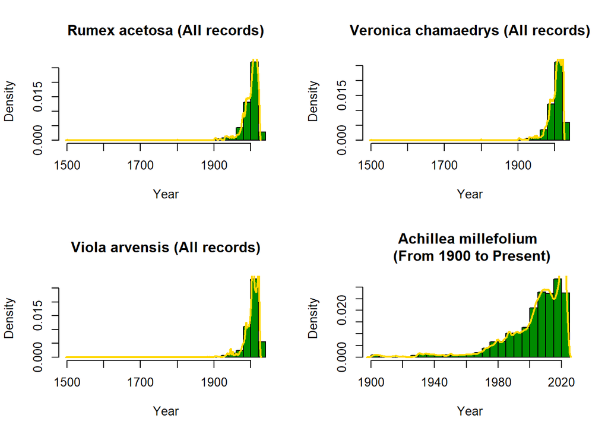

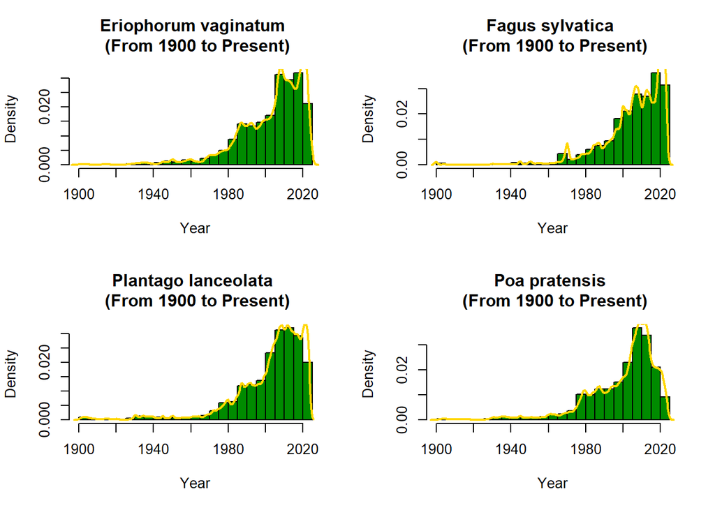

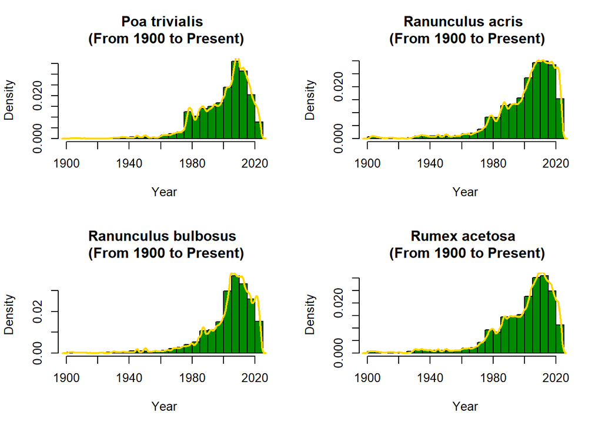

```r
# plotting from 1900 to the present
invisible(lapply(los,plantHist19))
```

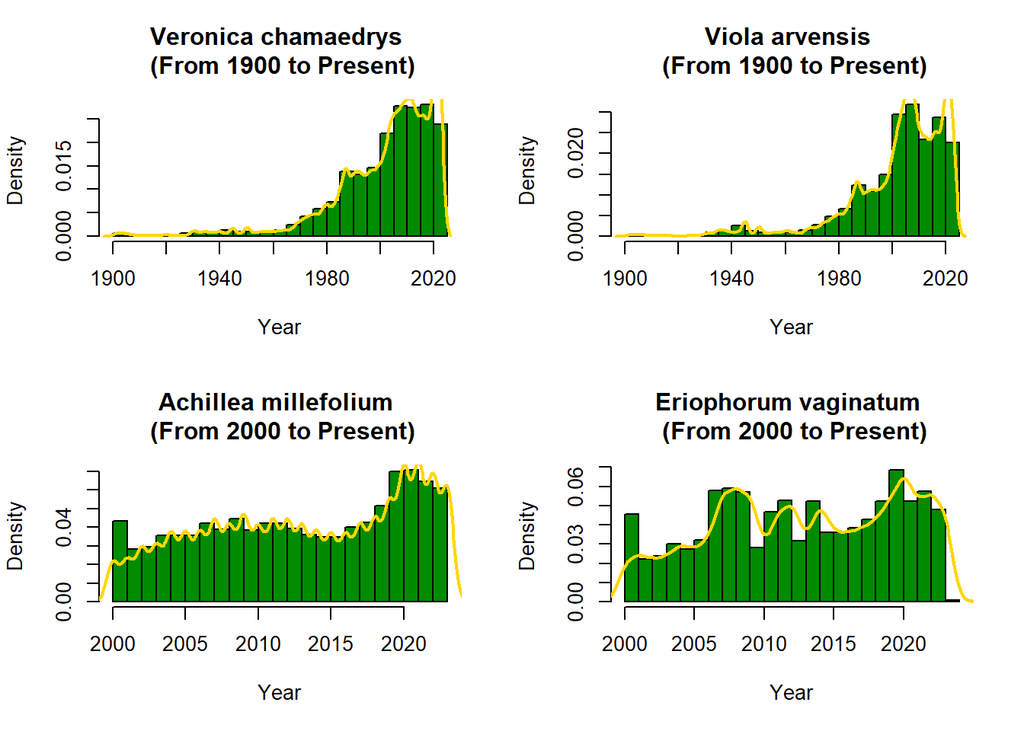

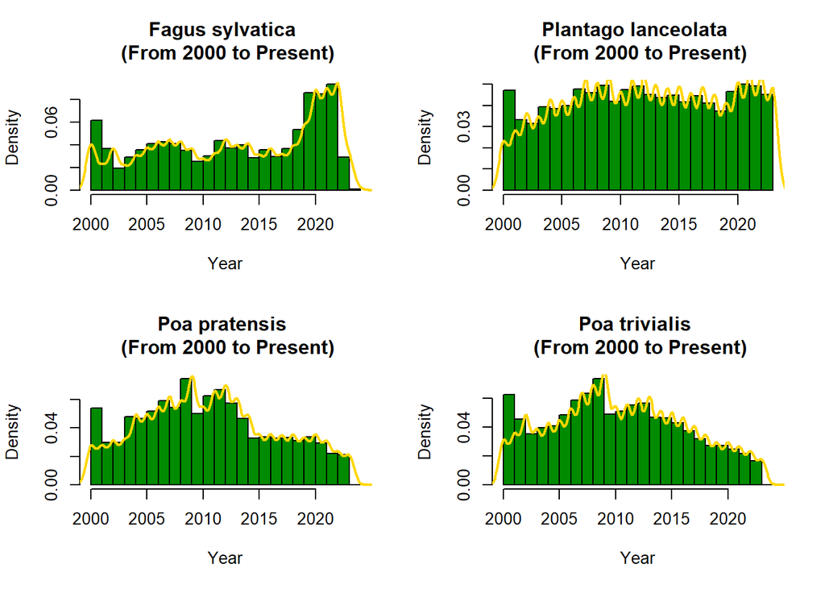

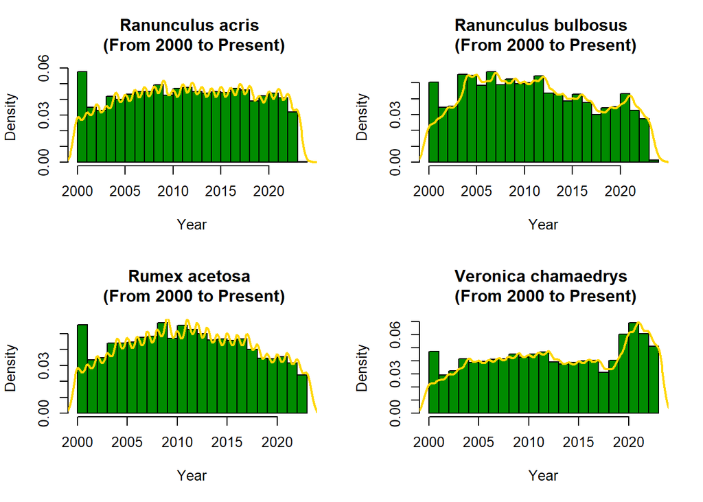

```r
# plotting from 2000 to the present
invisible(lapply(los,plantHist20))
```

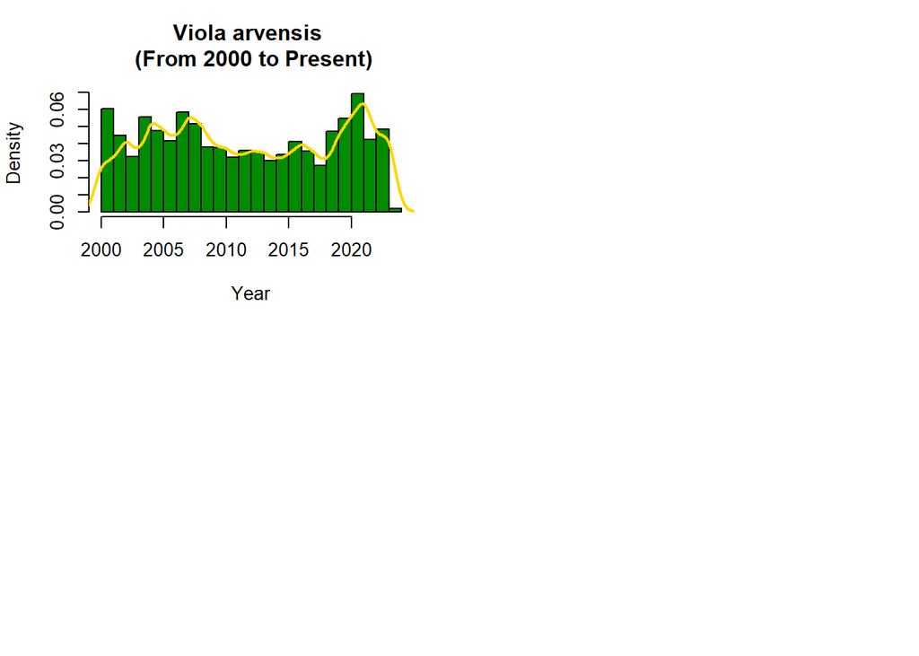

```
## [1] "COMPLETED IN..."
```

```
## Time difference of 48.15863 secs
```

```r
# remove unnecessary objects
rm(plantHist,plantHist19,plantHist20)
invisible(gc()) # to empty the memory
```

The histograms above show that the majority of the occurrence records are in the 21st century, with many of the species’ records of occurrence peaking around 2020. Due to this fact, we used the 2020 timestep (with the SSP 1 - RCP 2.6 scenario) as a baseline for land use.

### 2.2 – Land use Data Processing

To calculate habitat suitability (see section 2.3), files must be converted from NetCDF format to stacked raster format. To achieve this, the package `ncdf4` (Pierce, 2023), the package `raster` (Hijmans, 2023), the package `rgdal` (Bivand et al., 2023), and the package `terra` (Hijmans, 2024) were used.

```r
ncdf2rast <- function(i,nc){

  # load packages
  require(ncdf4) # package for netcdf manipulation
  require(raster) # package for raster manipulation
  require(rgdal) # package for geospatial analysis

  # open NetCDF file
  nc_data <- nc_open(paste0(nc,".nc"))

  # Save the print(nc) dump to a text file
  {
    sink(paste0(nc,".txt"))
    print(nc_data)
    sink()
  }

  # retrieving the longitude
  lon <- ncvar_get(nc_data, "longitude")
  lon[lon > 180] <- lon[lon > 180] - 360

  # retrieving the latitude
  lat <- ncvar_get(nc_data, "latitude", verbose = F)

  # retrieving variables
  var <- attributes(nc_data$var)
  var <- var$names

  # create array for variable nº i
  array <- ncvar_get(nc_data, var[i]) # store the data in a 3-dimensional array

  # retrieve fill value of variable nº i
  fillvalue <- ncatt_get(nc_data, var[i], "_FillValue")

  # change fill value to NA
  array[array == fillvalue$value] <- NA

  # turn array into raster object
  r <- raster(array, xmn=min(lon),
              xmx=max(lon),
              ymn=min(lat),
              ymx=max(lat),
              crs=CRS(SRS_string="+proj=longlat +ellps=WGS84 +datum=WGS84 +no_defs+ towgs84=0,0,0"))

  # free unused memory
  invisible(gc())

  # load package
  require("terra")

  # creat SpatRaster object
  r <- rast(r)

  # change name of layers to name of variables
  names(r) <- var[i]

  # close NetCDF file
  nc_close(nc_data)

  # return values
  return(r)
}

### rotating land use file for 2020 (SSP 1 - RCP 2.6 scenario)

# load package
library("terra")

# create object with the "i" number of variables
n <- c(1:33)

# create stacked raster
LU2020 <- do.call(c, lapply(n,ncdf2rast,nc = "LU/126/GCAM_Demeter_LU_ssp1_rcp26_modelmean_2020"))
invisible(gc())

# removing unnecessary objects
rm(n)
invisible(gc())

# exporting rotated stacked raster
writeRaster(LU2020,"LU2020.tif", overwrite = TRUE)

# removing unnecessary objects
rm(LU2020)
invisible(gc())

# (re-)importing land use data
LU2020 <- rast("LU2020.tif")
invisible(gc())
```

### 2.3 – Calculating the Suitability and the Habitat Suitability

The suitability index is calculated by summing the proportion of the land use class in the pixels in which the species occurs and then dividing these values by the maximum value obtained (Figure 2A). Then the suitability index value is multiplied by the raster layers of the respective land use classes. The habitat suitability index is obtained by summing all land use raster layers after multiplying the suitability index (Figure 2B). To achieve this, the package `terra` (Hijmans, 2024) was used.

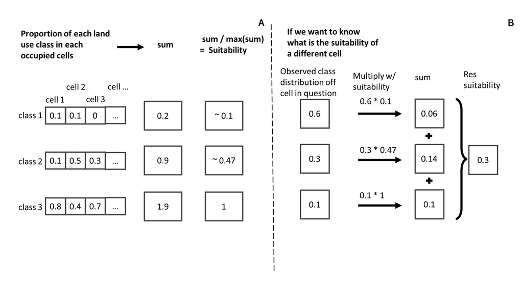

*Figure 2* - Graphical representation of how to calculate the habitat suitability index.

```r
# creating function to extract land use values from stacked raster
getLUalues <- function(vector,NetCDF){

  # import package
  require("terra", quietly = T)

  # processing dataset
  points <- subset(vector, select = c("decimalLongitude","decimalLatitude"))
  colnames(points) <- c("x","y")

  # extract values
  points <- as.data.frame(points)
  valuesatpoints <- extract(NetCDF, points)
  invisible(gc()) # to empty the memory
  points <- cbind(points,valuesatpoints)

  # These are the acronyms that are in the article
  colnames(points) <- c("lon","lat","ID","Water",
                        "NET_tem","NET_bor","NDT_bor","BET_tro",
                        "BET_tem","BDT_tro","BDT_tem","BDT_bor",
                        "BES_tem","BDS_tem","BDS_bor","C3_gra_arc",
                        "C3_gra","C4_gra","Corn_rf","Corn_irr",
                        "Wheat_rf","Wheat_irr","Soy_rf","Soy_irr",
                        "Cotton_rf","Cotton_irr","Rice_rf","Rice_irr",
                        "Sugarcrop_rf","Sugarcrop_irr","OtherCrop_rf","OtherCrop_irr",
                        "Bioenergy_rf","Bioenergy_irr","Urban","Barren")

  # These are the names that are in the .nc file
  # colnames(points) <- c("lat","lon","ID","PFT0",
  #                       "PFT1","PFT2","PFT3","PFT4",
  #                       "PFT5","PFT6","PFT7","PFT8",
  #                       "PFT9","PFT10","PFT11","PFT12",
  #                       "PFT13","PFT14","PFT15","PFT16",
  #                       "PFT17","PFT18","PFT19","PFT20",
  #                       "PFT21","PFT22","PFT23","PFT24",
  #                       "PFT25","PFT26","PFT27","PFT28",
  #                       "PFT29","PFT30","PFT31","PFT32")

  # These are the code names that are in the article
  # colnames(points) <- c("lat","lon","ID","FLT0",
  #                       "FLT1","FLT2","FLT3","FLT4",
  #                       "FLT5","FLT6","FLT7","FLT8",
  #                       "FLT9","FLT10","FLT11","FLT12",
  #                       "FLT13","FLT14","FLT15","FLT16",
  #                       "FLT17","FLT18","FLT19","FLT20",
  #                       "FLT21","FLT22","FLT23","FLT24",
  #                       "FLT25","FLT26","FLT27","FLT28",
  #                       "FLT29","FLT30","FLT31","FLT32")

  # calculating suitability
  SI <- (rowSums(t(points[,4:36]), na.rm = T)/max(rowSums(t(points[,4:36]), na.rm = T)));invisible(gc())

  # making the landuse class columns
  SI <- t(SI)

  # creating species column
  empty <- data.frame(`species` = unique(vector$species))

  # bringing it all up together
  df_SI <- cbind(empty,SI)

  # free unused memory
  invisible(gc())

  # return values
  return(df_SI)
}
```

### 2.4 – Clipping and Exporting the Habitat Suitability Layers

```r
# run the list of species through the function and combine the result into a single dataframe
SI <- do.call(rbind,lapply(los,getLUalues, NetCDF = LU2020))
invisible(gc())

# remove unnecessary objects
rm(LU2020)
invisible(gc())
```

The land use files are imported and clipped (to include only the Bavaria and Baden-Württemberg area) via the package `terra` (Hijmans, 2024) and the package `sf` (Pebesma, 2018). Thirdly, we use the calculated suitability values (section 2.3) and the stacked rasters clipped to the Bavaria and Baden-Württemberg area to calculate the habitat suitability of the target species at the desired timesteps and scenarios (scenarios SSP 1 - RCP 2.6 and SSP 5 - RCP 8.5). To achieve this, the package `ncdf4` (Pierce, 2023), the package `raster` (Hijmans, 2023), the package `rgdal` (Bivand et al., 2023), and the package `terra` (Hijmans, 2024) were used.

```r
# import paths
netlist <- append(list.files("LU/126", pattern = "nc", full.names=T),
                  list.files("LU/585", pattern = "nc", full.names=T))

# process paths
for(i in seq_along(netlist)){

  netlist[i] <- substr(netlist[i],1,nchar(netlist[i])-3)

  rm(i)
}
invisible(gc())

# load package
library("sf")

# import shapefile
shape <- read_sf("shapefiles/Bav_BW.shp")

# load package
library("terra")

# turn shapefile into SpatVector object
tShape <- vect(shape)

# remove unnecessary object
rm(shape)

# create suitability maps for all species
for(x in seq_along(netlist)){

  # create stacked raster
  n <- do.call(c, lapply(1:33,ncdf2rast,nc = netlist[x]))
  invisible(gc())

  # extent
  BavBW <- crop(n, ext(tShape))

  # masking time
  BavBW <- mask(BavBW,tShape)
  a <- varnames(n)
  rm(n)
  names(BavBW) <- a

  # creating list
  los <- SI$species

  for(i in seq_along(los)){

    r <- rast(ncol = 127, nrow = 66, xmin = 7.498959,
              xmax = 13.84808, ymin = 47.28686,
              ymax = 50.58594)
    r <- rep(r,33)

    SIn <- SI[,-1]

    for(z in seq_along(names(SIn[i,]))){

      r[[z]] <- BavBW[[z]]*SIn[i,z]
      invisible(gc())

    }

    r <- sum(r, na.rm = T)
    invisible(gc())

    #scenario name
    scenario <- substr(netlist[x],24,nchar(netlist[x]))

    # load package
    library("stringr")

    # species name
    species <- sub(" ", "", str_to_title(as.character(unique(SI[i,]$species))))

    # now save as CSV in MetaRange format
    metarange <- round(as.array(r))
    metarange[which(is.na(metarange))] <- "NaN"
    invisible(gc()) # garbage collection

    # Julia needs to have grid cells without values filled with "NaN"
    write.table(metarange,
                paste0("LU/Future/",scenario,"_",species,".csv"),
                col.names = F, row.names = F)

    # write as raster as well
    writeRaster(r,
                paste0("LU/Future/tif/",scenario,"_",species,".tif"),
                overwrite = T)

    invisible(gc()) # garbage collection

    rm(r,SIn,i,z,metarange)
  }
  rm(x,a,los,species,scenario)
}
```

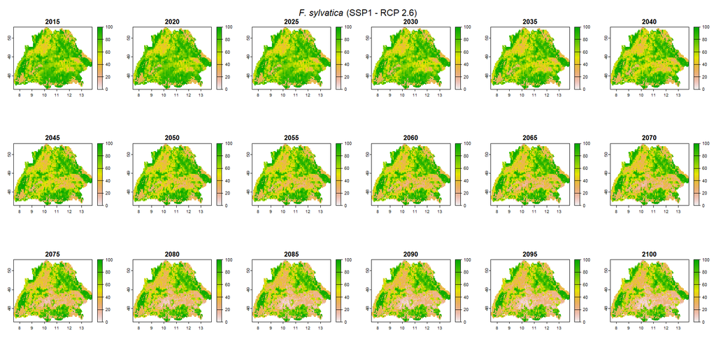

```r
# make list
HS_List <- list.files("LU/Future/tif", pattern = "tif", full.names=T)

# processing list (plotting result for the species F. sylvatica as an example - part 1)
Fsylvatica_list <- HS_List[which(substr(HS_List,41,54) == "FagusSylvatica")]
Fsylvatica_list <- Fsylvatica_list[c(1:18)]

# remove unnecessary objects
rm(HS_List)

# load package
library("terra")

# import data
Fsylvatica <- rast(Fsylvatica_list)

# structuring
par(mfrow = c(3,6))

# making the plots
for(i in seq_along(Fsylvatica_list)){

  plot(Fsylvatica[[i]],
       main = substr(Fsylvatica_list[i],36,39),
       range = c(0,100))

}
mtext(substitute(paste(italic('F. sylvatica')," (SSP1 - RCP 2.6)")), side = 3, line = - 2.75, outer = TRUE)

# remove unnecessary objects
rm(i,Fsylvatica,Fsylvatica_list)
```

## 3 – COMBINING HABITAT SUITABILITY (LAND USE DATA) WITH THE CLIMATE DATA

As previously mentioned, climate data are layers that correspond to 30-year intervals. However, land use data are layers that correspond to the land use predicted every 5 years from 2015 to 2100. In order to combine land use and climate data into a continuous time series, three steps are taken: (1) land use data is used at intervals of 5 years, that is, for example, the 2015 timestep starts to represent the 2011-2015 interval; (2) the climate data used are from the 2011-2040, 2041-2070, and 2071-2100 intervals, since these are the intervals that overlap with the land use data timesteps; and (3), To have a continuous time-series of land-use and climate, the data from both sources were matched by time-period. For example, the first interval of climate data is 2011-2040, so we now have a file for 2011, another for 2012, another for 2013, etc. until the year 2040; the same happens for land use data (in this case of habitat suitability), the first interval is 2011-2015, so we now have a file for 2011, another for 2012, another for 2013, another for 2014 and, finally, another for 2015.

```r
### CLIMATIC FILES ###

# load package
library("data.table")

# create list
clim_list <- list.files("clim/Future/Cropped", pattern = "csv", full.names=T)

# processing list (taking unwanted files)
clim_list <- clim_list[-c(4,11)]

# creating species vector
species <- c("AchilleaMillefolium","EriophorumVaginatum","FagusSylvatica",
             "PlantagoLanceolata","PoaPratensis","PoaTrivialis","RanunculusAcris",
             "RanunculusBulbosus","RumexAcetosa","VeronicaChamaedrys","ViolaArvensis" )

# creating files - part 1
for(j in seq_along(species)){
  for(i in seq_along(clim_list[c(1,4,7,10)])){
    k <- fread(clim_list[c(1,4,7,10)][i])
    for(c in seq_along(2011:2100)){
      if(c < 10){
        if(i == 1){
          write.table(k,paste0("outputs/",species[j],"/SSP1 - land use/environment/temperature/Bio01_0",c,".csv"),
              col.names = T, row.names = F, sep = " ",
              quote = FALSE)
        } else {
          if(i == 2){
            write.table(k,paste0("outputs/",species[j],"/SSP5 - land use/environment/temperature/Bio01_0",c,".csv"),
              col.names = T, row.names = F, sep = " ",
              quote = FALSE)
          } else {
            if(i == 3){
              write.table(k,paste0("outputs/",species[j],"/SSP1 - land use/environment/precipitation/Bio12_0",c,".csv"),
              col.names = T, row.names = F, sep = " ",
              quote = FALSE)
            } else {
            write.table(k,paste0("outputs/",species[j],"/SSP5 - land use/environment/precipitation/Bio12_0",c,".csv"),
              col.names = T, row.names = F, sep = " ",
              quote = FALSE)
            }
          }
        }
      } else {
        if(i == 1){
          write.table(k,paste0("outputs/",species[j],"/SSP1 - land use/environment/temperature/Bio01_",c,".csv"),
              col.names = T, row.names = F, sep = " ",
              quote = FALSE)
        } else {
          if(i == 2){
            write.table(k,paste0("outputs/",species[j],"/SSP5 - land use/environment/temperature/Bio01_",c,".csv"),
              col.names = T, row.names = F, sep = " ",
              quote = FALSE)
          } else {
            if(i == 3){
              write.table(k,paste0("outputs/",species[j],"/SSP1 - land use/environment/precipitation/Bio12_",c,".csv"),
              col.names = T, row.names = F, sep = " ",
              quote = FALSE)
            } else {
            write.table(k,paste0("outputs/",species[j],"/SSP5 - land use/environment/precipitation/Bio12_",c,".csv"),
              col.names = T, row.names = F, sep = " ",
              quote = FALSE)
            }
          }
        }
      }
    }
  }
}

# remove unnecessary objects
rm(i,j,k,c)

# creating files - part 2
for(z in seq_along(species)){
  for(i in seq_along(clim_list)){

  # import file
  a <- fread(clim_list[i])

  # if it is a temperature file for scenario 126
  if(substr(clim_list[i],21,29) == "bio01_126"){

    # if it is from the interval 2011-2040
    if(substr(clim_list[i],31,39) == "2011_2040"){

      for(x in seq_along(2011:2040)){

        # if the value of x is lower than 10
        if(x < 10){
          write.table(a,paste0("outputs/",species[z],"/SSP1 - climate/environment/temperature/Bio01_0",x,".csv"),
              col.names = T, row.names = F, sep = " ",
              quote = FALSE)
          write.table(a,paste0("outputs/",species[z],"/SSP1 - climate + land use/environment/temperature/Bio01_0",x,".csv"),
              col.names = T, row.names = F, sep = " ",
              quote = FALSE)
        } else {
          write.table(a,paste0("outputs/",species[z],"/SSP1 - climate/environment/temperature/Bio01_",x,".csv"),
              col.names = T, row.names = F, sep = " ",
              quote = FALSE)
          write.table(a,paste0("outputs/",species[z],"/SSP1 - climate + land use/environment/temperature/Bio01_",x,".csv"),
              col.names = T, row.names = F, sep = " ",
              quote = FALSE)
        }}

      # remove unnecessary objects
      rm(x)
    } else {
      # if it is from the interval 2041-2070
      if(substr(clim_list[i],31,39) == "2041_2070"){
        for(x in seq_along(2041:2070)+30){
         write.table(a,paste0("outputs/",species[z],"/SSP1 - climate/environment/temperature/Bio01_",x,".csv"),
              col.names = T, row.names = F, sep = " ",
              quote = FALSE)
          write.table(a,paste0("outputs/",species[z],"/SSP1 - climate + land use/environment/temperature/Bio01_",x,".csv"),
              col.names = T, row.names = F, sep = " ",
              quote = FALSE)
        }

        # remove unnecessary objects
        rm(x)
      } else {
         # if it is from the interval 2071-2100
         for(x in seq_along(2071:2100)+60){
         write.table(a,paste0("outputs/",species[z],"/SSP1 - climate/environment/temperature/Bio01_",x,".csv"),
              col.names = T, row.names = F, sep = " ",
              quote = FALSE)
          write.table(a,paste0("outputs/",species[z],"/SSP1 - climate + land use/environment/temperature/Bio01_",x,".csv"),
              col.names = T, row.names = F, sep = " ",
              quote = FALSE)
         }

        # remove unnecessary objects
        rm(x)
      }
    }
  } else {
    if(substr(clim_list[i],21,29) == "bio01_585"){
      # if it is from the interval 2011-2040
      if(substr(clim_list[i],31,39) == "2011_2040"){

        for(x in seq_along(2011:2040)){

          # if the value of x is lower than 10
          if(x < 10){
            write.table(a,paste0("outputs/",species[z],"/SSP5 - climate/environment/temperature/Bio01_0",x,".csv"),
                        col.names = T, row.names = F, sep = " ",
                        quote = FALSE)
            write.table(a,paste0("outputs/",species[z],"/SSP5 - climate + land use/environment/temperature/Bio01_0",x,".csv"),
                        col.names = T, row.names = F, sep = " ",
                        quote = FALSE)
            } else {
              write.table(a,paste0("outputs/",species[z],"/SSP5 - climate/environment/temperature/Bio01_",x,".csv"),
                          col.names = T, row.names = F, sep = " ",
                          quote = FALSE)
              write.table(a,paste0("outputs/",species[z],"/SSP5 - climate + land use/environment/temperature/Bio01_",x,".csv"),
                          col.names = T, row.names = F, sep = " ",
                          quote = FALSE)
              }}
```

```r
        # remove unnecessary objects
        rm(x)
        } else {
          # if it is from the interval 2041-2070
          if(substr(clim_list[i],31,39) == "2041_2070"){
            for(x in seq_along(2041:2070)+30){
              write.table(a,paste0("outputs/",species[z],"/SSP5 - climate/environment/temperature/Bio01_",x,".csv"),
                          col.names = T, row.names = F, sep = " ",
                          quote = FALSE)
              write.table(a,paste0("outputs/",species[z],"/SSP5 - climate + land use/environment/temperature/Bio01_",x,".csv"),
                          col.names = T, row.names = F, sep = " ",
                          quote = FALSE)
              }

            # remove unnecessary objects
            rm(x)
            } else {
              # if it is from the interval 2071-2100
              for(x in seq_along(2071:2100)+60){
                write.table(a,paste0("outputs/",species[z],"/SSP5 - climate/environment/temperature/Bio01_",x,".csv"),
                            col.names = T, row.names = F, sep = " ",
                            quote = FALSE)
                write.table(a,paste0("outputs/",species[z],"/SSP5 - climate + land use/environment/temperature/Bio01_",x,".csv"),
                            col.names = T, row.names = F, sep = " ",
                            quote = FALSE)
                }

              # remove unnecessary objects
              rm(x)
            }
        }
    } else {
      if(substr(clim_list[i],21,29) == "bio12_126"){
        # if it is from the interval 2011-2040
        if(substr(clim_list[i],31,39) == "2011_2040"){

          for(x in seq_along(2011:2040)){

            # if the value of x is lower than 10
            if(x < 10){
              write.table(a,paste0("outputs/",species[z],"/SSP1 - climate/environment/precipitation/Bio12_0",x,".csv"),
                          col.names = T, row.names = F, sep = " ",
                          quote = FALSE)
              write.table(a,paste0("outputs/",species[z],"/SSP1 - climate + land use/environment/precipitation/Bio12_0",x,".csv"),
                          col.names = T, row.names = F, sep = " ",
                          quote = FALSE)
            } else {
              write.table(a,paste0("outputs/",species[z],"/SSP1 - climate/environment/precipitation/Bio12_",x,".csv"),
                          col.names = T, row.names = F, sep = " ",
                          quote = FALSE)
              write.table(a,paste0("outputs/",species[z],"/SSP1 - climate + land use/environment/precipitation/Bio12_",x,".csv"),
                          col.names = T, row.names = F, sep = " ",
                          quote = FALSE)
              }}

        # remove unnecessary objects
        rm(x)
        } else {
          # if it is from the interval 2041-2070
          if(substr(clim_list[i],31,39) == "2041_2070"){
            for(x in seq_along(2041:2070)+30){
              write.table(a,paste0("outputs/",species[z],"/SSP1 - climate/environment/precipitation/Bio12_",x,".csv"),
                          col.names = T, row.names = F, sep = " ",
                          quote = FALSE)
              write.table(a,paste0("outputs/",species[z],"/SSP1 - climate + land use/environment/precipitation/Bio12_",x,".csv"),
                          col.names = T, row.names = F, sep = " ",
                          quote = FALSE)
              }

            # remove unnecessary objects
            rm(x)
            } else {
              # if it is from the interval 2071-2100
              for(x in seq_along(2071:2100)+60){
                write.table(a,paste0("outputs/",species[z],"/SSP1 - climate/environment/precipitation/Bio12_",x,".csv"),
                            col.names = T, row.names = F, sep = " ",
                            quote = FALSE)
                write.table(a,paste0("outputs/",species[z],"/SSP1 - climate + land use/environment/precipitation/Bio12_",x,".csv"),
                            col.names = T, row.names = F, sep = " ",
                            quote = FALSE)
                }

              # remove unnecessary objects
              rm(x)
            }
        }
      } else {
        # if it is from the interval 2011-2040
        if(substr(clim_list[i],31,39) == "2011_2040"){

          for(x in seq_along(2011:2040)){

            # if the value of x is lower than 10
            if(x < 10){
              write.table(a,paste0("outputs/",species[z],"/SSP5 - climate/environment/precipitation/Bio12_0",x,".csv"),
                          col.names = T, row.names = F, sep = " ",
                          quote = FALSE)
              write.table(a,paste0("outputs/",species[z],"/SSP5 - climate + land use/environment/precipitation/Bio12_0",x,".csv"),
                          col.names = T, row.names = F, sep = " ",
                          quote = FALSE)
            } else {
              write.table(a,paste0("outputs/",species[z],"/SSP5 - climate/environment/precipitation/Bio12_",x,".csv"),
                          col.names = T, row.names = F, sep = " ",
                          quote = FALSE)
              write.table(a,paste0("outputs/",species[z],"/SSP5 - climate + land use/environment/precipitation/Bio12_",x,".csv"),
                          col.names = T, row.names = F, sep = " ",
                          quote = FALSE)
              }}

        # remove unnecessary objects
        rm(x)
        } else {
          # if it is from the interval 2041-2070
          if(substr(clim_list[i],31,39) == "2041_2070"){
            for(x in seq_along(2041:2070)+30){
              write.table(a,paste0("outputs/",species[z],"/SSP5 - climate/environment/precipitation/Bio12_",x,".csv"),
                          col.names = T, row.names = F, sep = " ",
                          quote = FALSE)
              write.table(a,paste0("outputs/",species[z],"/SSP5 - climate + land use/environment/precipitation/Bio12_",x,".csv"),
                          col.names = T, row.names = F, sep = " ",
                          quote = FALSE)
              }
```

```r
            # remove unnecessary objects
            rm(x)
            } else {
              # if it is from the interval 2071-2100
              for(x in seq_along(2071:2100)+60){
                write.table(a,paste0("outputs/",species[z],"/SSP5 - climate/environment/precipitation/Bio12_",x,".csv"),
                            col.names = T, row.names = F, sep = " ",
                            quote = FALSE)
                write.table(a,paste0("outputs/",species[z],"/SSP5 - climate + land use/environment/precipitation/Bio12_",x,".csv"),
                            col.names = T, row.names = F, sep = " ",
                            quote = FALSE)
                }

              # remove unnecessary objects
              rm(x)
            }
        }
    }
    }
    }

  # remove unnecessary objects
  rm(a)
  }
}

# remove unnecessary objects
rm(clim_list,i,species)
invisible(gc())

### SUITABILITY FILES ###

# create list
species_list <- list.files("LU/Future", pattern = "csv", full.names=T)

# creating files
for(i in seq_along(species_list)){

  # import file
  a <- fread(species_list[i])

  # if it is from scenario 1.26
  if(substr(species_list[i],14,14) == 1){
    if(substr(species_list[i],32,35) == 2015){
      for(x in seq_along(2011:2015)){
        write.table(a/100,paste0("outputs/",substr(species_list[i],37,nchar(species_list[i])-4),"/SSP1 - land use/environment/suitability/HS_0",x,".csv"),
                          col.names = T, row.names = F, sep = " ",
                          quote = FALSE)
        write.table(a/100,paste0("outputs/",substr(species_list[i],37,nchar(species_list[i])-4),"/SSP1 - climate + land use/environment/suitability/HS_0",x,".csv"),
                          col.names = T, row.names = F, sep = " ",
                          quote = FALSE)
      }

      # remove unnecessary objects
      rm(x)
    } else {
      if(substr(species_list[i],32,35) == 2020){
        for(x in seq_along(2016:2020)+5){
          if(x < 10){
            write.table(a/100,paste0("outputs/",substr(species_list[i],37,nchar(species_list[i])-4),"/SSP1 - land use/environment/suitability/HS_0",x,".csv"),
                      col.names = T, row.names = F, sep = " ",
                      quote = FALSE)
            write.table(a/100,paste0("outputs/",substr(species_list[i],37,nchar(species_list[i])-4),"/SSP1 - climate + land use/environment/suitability/HS_0",x,".csv"),
                      col.names = T, row.names = F, sep = " ",
                      quote = FALSE)
          } else {
            write.table(a/100,paste0("outputs/",substr(species_list[i],37,nchar(species_list[i])-4),"/SSP1 - land use/environment/suitability/HS_",x,".csv"),
                      col.names = T, row.names = F, sep = " ",
                      quote = FALSE)
            write.table(a/100,paste0("outputs/",substr(species_list[i],37,nchar(species_list[i])-4),"/SSP1 - climate + land use/environment/suitability/HS_",x,".csv"),
                      col.names = T, row.names = F, sep = " ",
                      quote = FALSE)
          }
          }

      # remove unnecessary objects
      rm(x)
      } else {
        if(substr(species_list[i],32,35) == 2025){
          for(x in seq_along(2021:2025)+10){
            write.table(a/100,paste0("outputs/",substr(species_list[i],37,nchar(species_list[i])-4),"/SSP1 - land use/environment/suitability/HS_",x,".csv"),
                          col.names = T, row.names = F, sep = " ",
                          quote = FALSE)
            write.table(a/100,paste0("outputs/",substr(species_list[i],37,nchar(species_list[i])-4),"/SSP1 - climate + land use/environment/suitability/HS_",x,".csv"),
                          col.names = T, row.names = F, sep = " ",
                          quote = FALSE)
      }

      # remove unnecessary objects
      rm(x)
    } else {
      if(substr(species_list[i],32,35) == 2030){
        for(x in seq_along(2026:2030)+15){
        write.table(a/100,paste0("outputs/",substr(species_list[i],37,nchar(species_list[i])-4),"/SSP1 - land use/environment/suitability/HS_",x,".csv"),
                          col.names = T, row.names = F, sep = " ",
                          quote = FALSE)
        write.table(a/100,paste0("outputs/",substr(species_list[i],37,nchar(species_list[i])-4),"/SSP1 - climate + land use/environment/suitability/HS_",x,".csv"),
                          col.names = T, row.names = F, sep = " ",
                          quote = FALSE)
      }

      # remove unnecessary objects
      rm(x)
      } else {
        if(substr(species_list[i],32,35) == 2035){
          for(x in seq_along(2031:2035)+20){
            write.table(a/100,paste0("outputs/",substr(species_list[i],37,nchar(species_list[i])-4),"/SSP1 - land use/environment/suitability/HS_",x,".csv"),
                        col.names = T, row.names = F, sep = " ",
                          quote = FALSE)
            write.table(a/100,paste0("outputs/",substr(species_list[i],37,nchar(species_list[i])-4),"/SSP1 - climate + land use/environment/suitability/HS_",x,".csv"),
                          col.names = T, row.names = F, sep = " ",
                          quote = FALSE)
      }

      # remove unnecessary objects
      rm(x)
    } else {
      if(substr(species_list[i],32,35) == 2040){
        for(x in seq_along(2036:2040)+25){
            write.table(a/100,paste0("outputs/",substr(species_list[i],37,nchar(species_list[i])-4),"/SSP1 - land use/environment/suitability/HS_",x,".csv"),
                      col.names = T, row.names = F, sep = " ",
                      quote = FALSE)
            write.table(a/100,paste0("outputs/",substr(species_list[i],37,nchar(species_list[i])-4),"/SSP1 - climate + land use/environment/suitability/HS_",x,".csv"),
                      col.names = T, row.names = F, sep = " ",
                      quote = FALSE)
          }

      # remove unnecessary objects
      rm(x)
      } else {
        if(substr(species_list[i],32,35) == 2045){
          for(x in seq_along(2041:2045)+30){
            write.table(a/100,paste0("outputs/",substr(species_list[i],37,nchar(species_list[i])-4),"/SSP1 - land use/environment/suitability/HS_",x,".csv"),
                          col.names = T, row.names = F, sep = " ",
                          quote = FALSE)
            write.table(a/100,paste0("outputs/",substr(species_list[i],37,nchar(species_list[i])-4),"/SSP1 - climate + land use/environment/suitability/HS_",x,".csv"),
                          col.names = T, row.names = F, sep = " ",
                          quote = FALSE)
      }
```

```r
      # remove unnecessary objects
      rm(x)
    } else {
      if(substr(species_list[i],32,35) == 2050){
        for(x in seq_along(2046:2050)+35){
        write.table(a/100,paste0("outputs/",substr(species_list[i],37,nchar(species_list[i])-4),"/SSP1 - land use/environment/suitability/HS_",x,".csv"),
                          col.names = T, row.names = F, sep = " ",
                          quote = FALSE)
        write.table(a/100,paste0("outputs/",substr(species_list[i],37,nchar(species_list[i])-4),"/SSP1 - climate + land use/environment/suitability/HS_",x,".csv"),
                          col.names = T, row.names = F, sep = " ",
                          quote = FALSE)
      }

      # remove unnecessary objects
      rm(x)
      } else {
        if(substr(species_list[i],32,35) == 2055){
          for(x in seq_along(2051:2055)+40){
        write.table(a/100,paste0("outputs/",substr(species_list[i],37,nchar(species_list[i])-4),"/SSP1 - land use/environment/suitability/HS_",x,".csv"),
                          col.names = T, row.names = F, sep = " ",
                          quote = FALSE)
        write.table(a/100,paste0("outputs/",substr(species_list[i],37,nchar(species_list[i])-4),"/SSP1 - climate + land use/environment/suitability/HS_",x,".csv"),
                          col.names = T, row.names = F, sep = " ",
                          quote = FALSE)
      }

      # remove unnecessary objects
      rm(x)
    } else {
      if(substr(species_list[i],32,35) == 2060){
        for(x in seq_along(2056:2060)+45){
          write.table(a/100,paste0("outputs/",substr(species_list[i],37,nchar(species_list[i])-4),"/SSP1 - land use/environment/suitability/HS_",x,".csv"),
                          col.names = T, row.names = F, sep = " ",
                          quote = FALSE)
          write.table(a/100,paste0("outputs/",substr(species_list[i],37,nchar(species_list[i])-4),"/SSP1 - climate + land use/environment/suitability/HS_",x,".csv"),
                          col.names = T, row.names = F, sep = " ",
                          quote = FALSE)
      }

      # remove unnecessary objects
      rm(x)
      } else {
        if(substr(species_list[i],32,35) == 2065){
          for(x in seq_along(2061:2065)+50){
            write.table(a/100,paste0("outputs/",substr(species_list[i],37,nchar(species_list[i])-4),"/SSP1 - land use/environment/suitability/HS_",x,".csv"),
                        col.names = T, row.names = F, sep = " ",
                          quote = FALSE)
            write.table(a/100,paste0("outputs/",substr(species_list[i],37,nchar(species_list[i])-4),"/SSP1 - climate + land use/environment/suitability/HS_",x,".csv"),
                          col.names = T, row.names = F, sep = " ",
                          quote = FALSE)
      }

      # remove unnecessary objects
      rm(x)
    } else {
      if(substr(species_list[i],32,35) == 2070){
        for(x in seq_along(2066:2070)+55){
            write.table(a/100,paste0("outputs/",substr(species_list[i],37,nchar(species_list[i])-4),"/SSP1 - land use/environment/suitability/HS_",x,".csv"),
                      col.names = T, row.names = F, sep = " ",
                      quote = FALSE)
            write.table(a/100,paste0("outputs/",substr(species_list[i],37,nchar(species_list[i])-4),"/SSP1 - climate + land use/environment/suitability/HS_",x,".csv"),
                      col.names = T, row.names = F, sep = " ",
                      quote = FALSE)
          }

      # remove unnecessary objects
      rm(x)
      } else {
        if(substr(species_list[i],32,35) == 2075){
          for(x in seq_along(2071:2075)+60){
            write.table(a/100,paste0("outputs/",substr(species_list[i],37,nchar(species_list[i])-4),"/SSP1 - land use/environment/suitability/HS_",x,".csv"),
                          col.names = T, row.names = F, sep = " ",
                          quote = FALSE)
            write.table(a/100,paste0("outputs/",substr(species_list[i],37,nchar(species_list[i])-4),"/SSP1 - climate + land use/environment/suitability/HS_",x,".csv"),
                          col.names = T, row.names = F, sep = " ",
                          quote = FALSE)
      }

      # remove unnecessary objects
      rm(x)
    } else {
      if(substr(species_list[i],32,35) == 2080){
        for(x in seq_along(2076:2080)+65){
          write.table(a/100,paste0("outputs/",substr(species_list[i],37,nchar(species_list[i])-4),"/SSP1 - land use/environment/suitability/HS_",x,".csv"),
                          col.names = T, row.names = F, sep = " ",
                          quote = FALSE)
          write.table(a/100,paste0("outputs/",substr(species_list[i],37,nchar(species_list[i])-4),"/SSP1 - climate + land use/environment/suitability/HS_",x,".csv"),
                          col.names = T, row.names = F, sep = " ",
                          quote = FALSE)
      }

      # remove unnecessary objects
      rm(x)
      } else {
        if(substr(species_list[i],32,35) == 2085){
          for(x in seq_along(2081:2085)+70){
            write.table(a/100,paste0("outputs/",substr(species_list[i],37,nchar(species_list[i])-4),"/SSP1 - land use/environment/suitability/HS_",x,".csv"),
                      col.names = T, row.names = F, sep = " ",
                      quote = FALSE)
            write.table(a/100,paste0("outputs/",substr(species_list[i],37,nchar(species_list[i])-4),"/SSP1 - climate + land use/environment/suitability/HS_",x,".csv"),
                      col.names = T, row.names = F, sep = " ",
                      quote = FALSE)
          }

      # remove unnecessary objects
      rm(x)
      } else {
        if(substr(species_list[i],32,35) == 2090){
          for(x in seq_along(2086:2090)+75){
            write.table(a/100,paste0("outputs/",substr(species_list[i],37,nchar(species_list[i])-4),"/SSP1 - land use/environment/suitability/HS_",x,".csv"),
                          col.names = T, row.names = F, sep = " ",
                          quote = FALSE)
            write.table(a/100,paste0("outputs/",substr(species_list[i],37,nchar(species_list[i])-4),"/SSP1 - climate + land use/environment/suitability/HS_",x,".csv"),
                          col.names = T, row.names = F, sep = " ",
                          quote = FALSE)
      }
```

```r
      # remove unnecessary objects
      rm(x)
    } else {
      if(substr(species_list[i],32,35) == 2095){
        for(x in seq_along(2091:2095)+80){
          write.table(a/100,paste0("outputs/",substr(species_list[i],37,nchar(species_list[i])-4),"/SSP1 - land use/environment/suitability/HS_",x,".csv"),
                          col.names = T, row.names = F, sep = " ",
                          quote = FALSE)
          write.table(a/100,paste0("outputs/",substr(species_list[i],37,nchar(species_list[i])-4),"/SSP1 - climate + land use/environment/suitability/HS_",x,".csv"),
                          col.names = T, row.names = F, sep = " ",
                          quote = FALSE)
      }

      # remove unnecessary objects
      rm(x)
      } else {
        for(x in seq_along(2096:2100)+85){
          write.table(a/100,paste0("outputs/",substr(species_list[i],37,nchar(species_list[i])-4),"/SSP1 - land use/environment/suitability/HS_",x,".csv"),
                          col.names = T, row.names = F, sep = " ",
                          quote = FALSE)
          write.table(a/100,paste0("outputs/",substr(species_list[i],37,nchar(species_list[i])-4),"/SSP1 - climate + land use/environment/suitability/HS_",x,".csv"),
                          col.names = T, row.names = F, sep = " ",
                          quote = FALSE)
          }
        }
      }
        }
        }
      }
        }
      }
        }
      }
        }
      }
        }
      }
        }
      }
        }
      }
    } else {
    if(substr(species_list[i],32,35) == 2015){
      for(x in seq_along(2011:2015)){
        write.table(a/100,paste0("outputs/",substr(species_list[i],37,nchar(species_list[i])-4),"/SSP5 - land use/environment/suitability/HS_0",x,".csv"),
                          col.names = T, row.names = F, sep = " ",
                          quote = FALSE)
        write.table(a/100,paste0("outputs/",substr(species_list[i],37,nchar(species_list[i])-4),"/SSP5 - climate + land use/environment/suitability/HS_0",x,".csv"),
                          col.names = T, row.names = F, sep = " ",
                          quote = FALSE)
      }

      # remove unnecessary objects
      rm(x)
    } else {
      if(substr(species_list[i],32,35) == 2020){
        for(x in seq_along(2016:2020)+5){
          if(x < 10){
            write.table(a/100,paste0("outputs/",substr(species_list[i],37,nchar(species_list[i])-4),"/SSP5 - land use/environment/suitability/HS_0",x,".csv"),
                      col.names = T, row.names = F, sep = " ",
                      quote = FALSE)
            write.table(a/100,paste0("outputs/",substr(species_list[i],37,nchar(species_list[i])-4),"/SSP5 - climate + land use/environment/suitability/HS_0",x,".csv"),
                      col.names = T, row.names = F, sep = " ",
                      quote = FALSE)
          } else {
            write.table(a/100,paste0("outputs/",substr(species_list[i],37,nchar(species_list[i])-4),"/SSP5 - land use/environment/suitability/HS_",x,".csv"),
                      col.names = T, row.names = F, sep = " ",
                      quote = FALSE)
            write.table(a/100,paste0("outputs/",substr(species_list[i],37,nchar(species_list[i])-4),"/SSP5 - climate + land use/environment/suitability/HS_",x,".csv"),
                      col.names = T, row.names = F, sep = " ",
                      quote = FALSE)
          }
          }

      # remove unnecessary objects
      rm(x)
      } else {
        if(substr(species_list[i],32,35) == 2025){
          for(x in seq_along(2021:2025)+10){
            write.table(a/100,paste0("outputs/",substr(species_list[i],37,nchar(species_list[i])-4),"/SSP5 - land use/environment/suitability/HS_",x,".csv"),
                          col.names = T, row.names = F, sep = " ",
                          quote = FALSE)
            write.table(a/100,paste0("outputs/",substr(species_list[i],37,nchar(species_list[i])-4),"/SSP5 - climate + land use/environment/suitability/HS_",x,".csv"),
                          col.names = T, row.names = F, sep = " ",
                          quote = FALSE)
      }

      # remove unnecessary objects
      rm(x)
    } else {
      if(substr(species_list[i],32,35) == 2030){
        for(x in seq_along(2026:2030)+15){
        write.table(a/100,paste0("outputs/",substr(species_list[i],37,nchar(species_list[i])-4),"/SSP5 - land use/environment/suitability/HS_",x,".csv"),
                          col.names = T, row.names = F, sep = " ",
                          quote = FALSE)
        write.table(a/100,paste0("outputs/",substr(species_list[i],37,nchar(species_list[i])-4),"/SSP5 - climate + land use/environment/suitability/HS_",x,".csv"),
                          col.names = T, row.names = F, sep = " ",
                          quote = FALSE)
      }

      # remove unnecessary objects
      rm(x)
      } else {
        if(substr(species_list[i],32,35) == 2035){
          for(x in seq_along(2031:2035)+20){
            write.table(a/100,paste0("outputs/",substr(species_list[i],37,nchar(species_list[i])-4),"/SSP5 - land use/environment/suitability/HS_",x,".csv"),
                        col.names = T, row.names = F, sep = " ",
                          quote = FALSE)
            write.table(a/100,paste0("outputs/",substr(species_list[i],37,nchar(species_list[i])-4),"/SSP5 - climate + land use/environment/suitability/HS_",x,".csv"),
                          col.names = T, row.names = F, sep = " ",
                          quote = FALSE)
      }

      # remove unnecessary objects
      rm(x)
    } else {
      if(substr(species_list[i],32,35) == 2040){
        for(x in seq_along(2036:2040)+25){
            write.table(a/100,paste0("outputs/",substr(species_list[i],37,nchar(species_list[i])-4),"/SSP5 - land use/environment/suitability/HS_",x,".csv"),
                      col.names = T, row.names = F, sep = " ",
                      quote = FALSE)
            write.table(a/100,paste0("outputs/",substr(species_list[i],37,nchar(species_list[i])-4),"/SSP5 - climate + land use/environment/suitability/HS_",x,".csv"),
                      col.names = T, row.names = F, sep = " ",
                      quote = FALSE)
          }
```

```r
      # remove unnecessary objects
      rm(x)
      } else {
        if(substr(species_list[i],32,35) == 2045){
          for(x in seq_along(2041:2045)+30){
            write.table(a/100,paste0("outputs/",substr(species_list[i],37,nchar(species_list[i])-4),"/SSP5 - land use/environment/suitability/HS_",x,".csv"),
                          col.names = T, row.names = F, sep = " ",
                          quote = FALSE)
            write.table(a/100,paste0("outputs/",substr(species_list[i],37,nchar(species_list[i])-4),"/SSP5 - climate + land use/environment/suitability/HS_",x,".csv"),
                          col.names = T, row.names = F, sep = " ",
                          quote = FALSE)
      }

      # remove unnecessary objects
      rm(x)
    } else {
      if(substr(species_list[i],32,35) == 2050){
        for(x in seq_along(2046:2050)+35){
        write.table(a/100,paste0("outputs/",substr(species_list[i],37,nchar(species_list[i])-4),"/SSP5 - land use/environment/suitability/HS_",x,".csv"),
                          col.names = T, row.names = F, sep = " ",
                          quote = FALSE)
        write.table(a/100,paste0("outputs/",substr(species_list[i],37,nchar(species_list[i])-4),"/SSP5 - climate + land use/environment/suitability/HS_",x,".csv"),
                          col.names = T, row.names = F, sep = " ",
                          quote = FALSE)
      }

      # remove unnecessary objects
      rm(x)
      } else {
        if(substr(species_list[i],32,35) == 2055){
          for(x in seq_along(2051:2055)+40){
        write.table(a/100,paste0("outputs/",substr(species_list[i],37,nchar(species_list[i])-4),"/SSP5 - land use/environment/suitability/HS_",x,".csv"),
                          col.names = T, row.names = F, sep = " ",
                          quote = FALSE)
        write.table(a/100,paste0("outputs/",substr(species_list[i],37,nchar(species_list[i])-4),"/SSP5 - climate + land use/environment/suitability/HS_",x,".csv"),
                          col.names = T, row.names = F, sep = " ",
                          quote = FALSE)
      }

      # remove unnecessary objects
      rm(x)
    } else {
      if(substr(species_list[i],32,35) == 2060){
        for(x in seq_along(2056:2060)+45){
          write.table(a/100,paste0("outputs/",substr(species_list[i],37,nchar(species_list[i])-4),"/SSP5 - land use/environment/suitability/HS_",x,".csv"),
                          col.names = T, row.names = F, sep = " ",
                          quote = FALSE)
          write.table(a/100,paste0("outputs/",substr(species_list[i],37,nchar(species_list[i])-4),"/SSP5 - climate + land use/environment/suitability/HS_",x,".csv"),
                          col.names = T, row.names = F, sep = " ",
                          quote = FALSE)
      }

      # remove unnecessary objects
      rm(x)
      } else {
        if(substr(species_list[i],32,35) == 2065){
          for(x in seq_along(2061:2065)+50){
            write.table(a/100,paste0("outputs/",substr(species_list[i],37,nchar(species_list[i])-4),"/SSP5 - land use/environment/suitability/HS_",x,".csv"),
                        col.names = T, row.names = F, sep = " ",
                          quote = FALSE)
            write.table(a/100,paste0("outputs/",substr(species_list[i],37,nchar(species_list[i])-4),"/SSP5 - climate + land use/environment/suitability/HS_",x,".csv"),
                          col.names = T, row.names = F, sep = " ",
                          quote = FALSE)
      }

      # remove unnecessary objects
      rm(x)
    } else {
      if(substr(species_list[i],32,35) == 2070){
        for(x in seq_along(2066:2070)+55){
            write.table(a/100,paste0("outputs/",substr(species_list[i],37,nchar(species_list[i])-4),"/SSP5 - land use/environment/suitability/HS_",x,".csv"),
                      col.names = T, row.names = F, sep = " ",
                      quote = FALSE)
            write.table(a/100,paste0("outputs/",substr(species_list[i],37,nchar(species_list[i])-4),"/SSP5 - climate + land use/environment/suitability/HS_",x,".csv"),
                      col.names = T, row.names = F, sep = " ",
                      quote = FALSE)
          }

      # remove unnecessary objects
      rm(x)
      } else {
        if(substr(species_list[i],32,35) == 2075){
          for(x in seq_along(2071:2075)+60){
            write.table(a/100,paste0("outputs/",substr(species_list[i],37,nchar(species_list[i])-4),"/SSP5 - land use/environment/suitability/HS_",x,".csv"),
                          col.names = T, row.names = F, sep = " ",
                          quote = FALSE)
            write.table(a/100,paste0("outputs/",substr(species_list[i],37,nchar(species_list[i])-4),"/SSP5 - climate + land use/environment/suitability/HS_",x,".csv"),
                          col.names = T, row.names = F, sep = " ",
                          quote = FALSE)
      }

      # remove unnecessary objects
      rm(x)
    } else {
      if(substr(species_list[i],32,35) == 2080){
        for(x in seq_along(2076:2080)+65){
          write.table(a/100,paste0("outputs/",substr(species_list[i],37,nchar(species_list[i])-4),"/SSP5 - land use/environment/suitability/HS_",x,".csv"),
                          col.names = T, row.names = F, sep = " ",
                          quote = FALSE)
          write.table(a/100,paste0("outputs/",substr(species_list[i],37,nchar(species_list[i])-4),"/SSP5 - climate + land use/environment/suitability/HS_",x,".csv"),
                          col.names = T, row.names = F, sep = " ",
                          quote = FALSE)
      }

      # remove unnecessary objects
      rm(x)
      } else {
        if(substr(species_list[i],32,35) == 2085){
          for(x in seq_along(2081:2085)+70){
            write.table(a/100,paste0("outputs/",substr(species_list[i],37,nchar(species_list[i])-4),"/SSP5 - land use/environment/suitability/HS_",x,".csv"),
                      col.names = T, row.names = F, sep = " ",
                      quote = FALSE)
            write.table(a/100,paste0("outputs/",substr(species_list[i],37,nchar(species_list[i])-4),"/SSP5 - climate + land use/environment/suitability/HS_",x,".csv"),
                      col.names = T, row.names = F, sep = " ",
                      quote = FALSE)
          }
```

```r
      # remove unnecessary objects
      rm(x)
      } else {
        if(substr(species_list[i],32,35) == 2090){
          for(x in seq_along(2086:2090)+75){
            write.table(a/100,paste0("outputs/",substr(species_list[i],37,nchar(species_list[i])-4),"/SSP5 - land use/environment/suitability/HS_",x,".csv"),
                          col.names = T, row.names = F, sep = " ",
                          quote = FALSE)
            write.table(a/100,paste0("outputs/",substr(species_list[i],37,nchar(species_list[i])-4),"/SSP5 - climate + land use/environment/suitability/HS_",x,".csv"),
                          col.names = T, row.names = F, sep = " ",
                          quote = FALSE)
      }

      # remove unnecessary objects
      rm(x)
    } else {
      if(substr(species_list[i],32,35) == 2095){
        for(x in seq_along(2091:2095)+80){
          write.table(a/100,paste0("outputs/",substr(species_list[i],37,nchar(species_list[i])-4),"/SSP5 - land use/environment/suitability/HS_",x,".csv"),
                          col.names = T, row.names = F, sep = " ",
                          quote = FALSE)
          write.table(a/100,paste0("outputs/",substr(species_list[i],37,nchar(species_list[i])-4),"/SSP5 - climate + land use/environment/suitability/HS_",x,".csv"),
                          col.names = T, row.names = F, sep = " ",
                          quote = FALSE)
      }

      # remove unnecessary objects
      rm(x)
      } else {
        for(x in seq_along(2096:2100)+85){
          write.table(a/100,paste0("outputs/",substr(species_list[i],37,nchar(species_list[i])-4),"/SSP5 - land use/environment/suitability/HS_",x,".csv"),
                          col.names = T, row.names = F, sep = " ",
                          quote = FALSE)
          write.table(a/100,paste0("outputs/",substr(species_list[i],37,nchar(species_list[i])-4),"/SSP5 - climate + land use/environment/suitability/HS_",x,".csv"),
                          col.names = T, row.names = F, sep = " ",
                          quote = FALSE)
        }
      }
    }
      }
      }
    }
      }
    }
      }
    }
      }
    }
      }
    }
      }
    }
      }
    }

  }

  # remove unnecessary objects
  rm(a)
}

# remove unnecessary objects
rm(i,x,species_list,a,z)
invisible(gc())
```

[output not shown]

[output not shown]

# REFERENCES

Bivand, R., Keitt, T., & Rowlingson, B. (2023). `rgdal`: Bindings for the “Geospatial” Data Abstraction Library. https://CRAN.R-project.org/package=rgdal

Chen, M., Vernon, C. R., Graham, N. T., Hejazi, M., Huang, M., Cheng, Y., & Calvin, K. (2020). Global land use for 2015–2100 at 0.05° resolution under diverse socioeconomic and climate scenarios. Scientific Data, 7(1), 320. https://doi.org/10.1038/s41597-020-00669-x

Hijmans, R. J. (2023). `raster`: Geographic Data Analysis and Modeling. https://CRAN.R-project.org/package=raster

Hijmans, R. J. (2024). `terra`: Spatial Data Analysis. https://CRAN.R-project.org/package=terra

Karger, D. N., Conrad, O., Böhner, J., Kawohl, T., Kreft, H., Soria-Auza, R. W., Zimmermann, N. E., Linder, H. P., & Kessler, M. (2017). Climatologies at high resolution for the earth’s land surface areas. Scientific Data, 4(1), 170122. https://doi.org/10.1038/sdata.2017.122

Pebesma, E. (2018). Simple Features for R: Standardized Support for Spatial Vector Data. The R Journal, 10(1), 439. https://doi.org/10.32614/RJ-2018-009

Pierce, D. (2023). `ncdf4`: Interface to Unidata netCDF (Version 4 or Earlier) Format Data Files. https://CRAN.R-project.org/package=ncdf4

R Core Team. (2022). R: A Language and Environment for Statistical Computing. R Foundation for Statistical Computing. https://www.R-project.org/